# Аванесян К.А. — Защита диссертации: некогнитивные навыки и занятость молодежи

Статичный просмотр презентации: слайды идут по порядку, интерактивные элементы отключены. Интерактивная версия открывается в браузере на экране шире 900 px (ноутбук, планшет в альбомной ориентации).

Аванесян Карен Алексеевич

Влияние некогнитивных навыков на характеристики занятости молодежи

Диссертация на соискание учёной степени кандидата экономических наук

Научный руководитель**д.э.н., профессор М. А. Боровская**

**24 сентября 2026 года**

Актуальность

## Почему некогнитивные навыки — и почему именно молодежь

Почему навыки

1

**Сдвиг спроса.** Рутинные задачи автоматизируются; резильентность, мотивация, эмпатия и любопытство — в топ-10 востребованных навыков (Autor et al., 2003; Deming, 2017; WEF, 2025)

2

**Пределы традиционных метрик.** При одинаковом образовании и стаже результаты разные; то, что уравнение Минсера относило к «ненаблюдаемым способностям» в ошибке модели, экономика теперь измеряет как некогнитивные навыки — ещё одно измерение человеческого капитала (Heckman et al., 2006; Cunha & Heckman, 2007; Humphries & Kosse, 2017)

3

**Роль навыков подтверждена** для занятости и зарплат в развитых и развивающихся странах (Almlund et al., 2011; Nordman et al., 2015), в том числе для молодежи (Glewwe et al., 2017; Lerman, 2013; Ripamonti, 2023)

Почему молодежь 15–29 лет

1

Вход без сигналов

стажа и послужного списка нет — навыки ускоряют поиск работы через социальный капитал и замещают формальную квалификацию (Baay et al., 2014; Akay & Yilmaz, 2023)

2

Самая уязвимая группа

переход «учёба — работа»: риски NEET, избыточного образования и профессионального несоответствия (Avanesian et al., 2024; Зудина, 2022)

3

Стартовые условия неравны

на входе на рынок труда профессионального опыта ещё мало, а условия старта — образование, ресурсы семьи — уже различаются. Могут ли некогнитивные навыки помочь? (Cunha & Heckman, 2007; Akay & Yilmaz, 2023)

Ключевое понятие

## Некогнитивные навыки: «Большая пятёрка»

Устойчивые паттерны мышления, чувств и поведения (Borghans et al., 2008) — трактуются как навыки: продуктивны · развиваемы · результат социализации (Green, 2013)

Открытость новому опыту

Любознательность, креативность, когнитивная гибкость

механизм →

Механизм

Предпочтение нерутинных задач и автономии → самоотбор в умственный труд

← черта

Добросовестность

Самодисциплина, упорство, ориентация на результат

механизм →

Механизм

«Сигнал готовности к работе» для работодателя; саморегуляция усилий

← черта

Экстраверсия

Социальная активность, коммуникация, позитивный аффект

механизм →

Механизм

Социальные сети и коммуникация → эффективность поиска работы

← черта

Доброжелательность

Кооперация, эмпатия, склонность к компромиссу

механизм →

Механизм

Командность — но слабое лоббирование собственных интересов

← черта

Эмоциональная стабильность

Стрессоустойчивость, низкая тревожность

механизм →

Механизм

Регуляция стрессовых реакций и усилий; буфер неопределённости

← черта

**Теория трактует связь как причинную:** черты — предопределённые (ex-ante) диспозиции, действующие через поведенческие механизмы — поиск работы, производительность, самоотбор в задачи, восприятие работы. Механизмы по чертам: Almlund et al., 2011; Borghans et al., 2008; Heckman & Kautz, 2012; Judge et al., 2002

Теоретическая рамка

## Навыки как механизм конвертации ресурсов в результаты

Теория человеческого капитала

Навыки и знания — капитал, создающий ценность через производительность (Becker, 1964; Mincer, 1974)

Расширение Дж. Хекмана

Производственная функция капитала включает черты личности; «навыки порождают навыки» (Heckman et al., 2006)

Динамическая комплементарность

Накопленные навыки повышают отдачу от последующих вложений; условия формирования связаны с экономической отдачей → связь различается по образованию и ресурсам семьи (Cunha & Heckman, 2007)

Степень разработки проблемы

## Что установлено — и что не изучено

| Черта / фактор | Что установлено | Источник |
| --- | --- | --- |
| Все пять черт | влияет на характеристики занятости молодежи | Buhl, 2007 |
| ЭкстраверсияЭмоц. стабильность | повышают успешность поиска работы — часто через социальный капитал | Baay et al., 2014 |
| Добросовестность | предсказывает успех в карьере; низкая эмоциональная стабильность подрывает его | Judge et al., 1999 |
| ЭкстраверсияОткрытость | у мигрантов сильнее предсказывают трудоустройство; экстраверсия замещает формальную квалификацию | Akay & Yilmaz, 2023 |
| Когнитивные + некогнитивные | влияют на вероятность занятости в профессиях умственного труда | Heckman, Stixrud & Urzua, 2006 |
| Открытость | когнитивная гибкость и склонность к нерутинным задачам → предпочтение должностей с принятием решений | Costa & McCrae, 1992 |
| Некогнитивные навыки | **Россия:** переход «учёба — работа» и NEET; неравенство во владении навыками между группами | Avanesian et al., 2024; Зудина, 2022; Гимпельсон и др., 2020 |

Что не изучено

**Молодежь**большинство работ — на населении в трудоспособном возрасте; потенциал навыков при выходе на рынок труда остаётся без внимания

**Субъективное качество занятости**экономическая литература сосредоточена на наличии работы и размере зарплаты

**Неоднородность эффектов**нет комплексного анализа по предопределённым ex-ante условиям, заданным до выхода на рынок труда

← общие для всех трёх результатов пробелы — предмет диссертации

Вопрос исследования

## Факт влияния установлен — не изучена его неоднородность

Главный вопрос

Помогают ли личностные навыки молодежи с меньшими ресурсами — или сильнее проявляются при более благоприятном старте?

Компенсация

Навыки **замещают** недостающие ресурсы: слабый образовательный сигнал, ограниченные возможности семьи → эффект сильнее у молодежи с менее благоприятным стартом (Akay & Yilmaz, 2023)

Комплементарность

Ресурсы **усиливают** отдачу от навыков: образование и родительские инвестиции создают среду, где черты конвертируются в преимущества → эффект сильнее при благоприятном старте (Cunha & Heckman, 2007)

**Теория допускает оба ответа**, а литература оценивает средний эффект: систематической оценки неоднородности связи по предопределённым условиям — положению семьи, образованию, полу, а также по распределению заработной платы — для молодежи нет. Это и есть главная задача диссертации.

Дизайн исследования

## Цель, этапы и задачи

Объект

Российская молодежь 15–29 лет на рынке труда

Предмет

Влияние некогнитивных навыков на вероятность и качество занятости, заработную плату и удовлетворенность работой

Цель

Оценить **степень и неоднородность** влияния некогнитивных навыков на объективные и субъективные характеристики занятости молодежи

1

Доступ к занятости и её качество

вход на рынок труда · глава 4

1

Оценить связь навыков с **формальной занятостью** и её вариацию по богатству семьи, образованию и полу

2

Установить связь с **качеством занятости**: умственный труд, избыточное образование

2

Вознаграждение — заработная плата

цена навыков · глава 5

3

Оценить **неоднородность отдачи** на разных участках распределения заработной платы

4

Определить **опосредующую роль образования** и различия отдачи между группами

3

Субъективное качество — удовлетворенность работой

оценка работы самим работником · глава 6

5

Оценить связь с **удовлетворенностью работой** и её компонентами по квинтилям зарплаты

Дизайн исследования

## Гипотезы исследования

1

Формальная занятость и её характеристики

Задачи 1–2 · глава 4

Оценить связь навыков с формальной занятостью и её вариацию по предопределённым условиям; установить связь с качеством занятости

Н1навыки положительно связаны с вероятностью формальной занятости

Н2эффект модерируется стартовым социально-экономическим положением семьи, уровнем образования и полом

Н3навыки положительно связаны с занятостью в высококвалифицированных должностях умственного труда

Н4навыки снижают вероятность избыточного образования у молодежи с высшим образованием

2

Заработная плата

Задачи 3–4 · глава 5

Оценить неоднородность отдачи по распределению заработной платы; определить опосредующую роль образования и различия между группами

Н5навыки положительно связаны с заработной платой

Н6отдача варьируется по положению работника в распределении заработной платы

Н7отдача частично опосредуется формальным образованием

Н8после учёта образования навыки сохраняют значимую связь с заработной платой

Н9отдача варьируется по полу, уровню образования и этапу жизненного цикла

3

Удовлетворенность работой

Задача 5 · глава 6

Оценить связь навыков с общей удовлетворенностью работой и её компонентами и вариативность связи по квинтилям заработной платы

Н10навыки положительно связаны с общей удовлетворенностью работой

Н11связь варьируется по положению работника в распределении заработной платы

Н12навыки связаны с отдельными компонентами удовлетворенности: условия труда, карьерный рост, оплата

Методология · Информационная база

## РМЭЗ НИУ ВШЭ: волны 2016 и 2019 годов

5 981

наблюдение: 3 315 (2016) + 2 666 (2019), несбалансированная панель

15–29 лет

возраст по определению МОТ; средний — 22.7 года; 52% женщин

40%

формально заняты — исход первого этапа анализа

40%

продолжают обучение: совмещают учёбу и первые шаги на рынке труда

Завершённое образование, % выборки

29%

22%

28%

21%

Ниже среднего Среднее Среднее проф. Высшее

Аналитические выборки по этапам

Этап 1 · Занятость**5 981**

Этап 2 · Зарплата (занятые по найму)**2 661**

Этап 3 · Удовлетворенность работой**2 924**

Источник: РМЭЗ НИУ ВШЭ, 2016 и 2019; блок «Большой пятёрки» включён в обе волны · код и данные исследования открыты: github.com/karavan88/Thesis

Методология · Вызовы

## Эндогенность навыков: пять источников смещения

Наивная оценка коэффициента при навыках смещена: ошибка модели коррелирует с регрессором. Пять причин — и что каждая из них искажает.

1 · Ненаблюдаемая гетерогенность

способности, здоровье, мотивация влияют и на черты, и на занятость → коэффициент навыков «присваивает» чужой эффект

2 · Пропущенные переменные

региональный рынок труда, когорта и возрастная стадия задают базовый уровень занятости независимо от навыков

3 · Спутывание стартовыми условиями

ресурсы семьи формируют и черты, и результаты (Cunha, Heckman, 2007): без учёта — эффект семьи выглядит эффектом навыков

4 · Самоотбор в занятость

зарплата и удовлетворённость наблюдаются только у занятых, а занятые — не случайная подвыборка молодежи

5 · Обратная причинность

занятость и заработок могут менять черты; в панели навыки измерены не всегда до результата → полностью не устраняется

Задача стратегии

не претендуя на каузальную идентификацию — снять каждое смещение, которое можно снять на этих данных, и честно обозначить оставшееся → следующий слайд

Методология · Эконометрическая стратегия

## Смешанные модели со случайными эффектами

Метод

Линейные смешанные модели вероятности в спецификации Бэйтса — **lme4** (Bates et al., 2015), оценка REML

**Случайные константы:** индивид · регион · возраст · **Случайные коэффициенты навыков** по группам: богатство семьи, образование, пол · **Взвешивание** обратной вероятности занятости (IPW) · для зарплаты — квантильная версия (LQMM)

Как модель снимает смещения

Наивная оценка

коэффициент при навыках смещён: ошибка коррелирует с регрессором

→

Фильтр 1 · Случайные константы

индивид · регион · возраст

гетерогенность индивида, региона, возраста; кластерность панели (вызовы 1–2)

→

Фильтр 2 · Случайные коэффициенты

навыки × богатство семьи, образование, пол

стартовые условия — контроли и модераторы: спутывание снято, неоднородность оценена (вызов 3)

→

Фильтр 3 · IPW

взвешивание обратной вероятности занятости

самоотбор в занятость по наблюдаемым (вызов 4)

→

Оценка

условная связь, очищенная от основных смещений

остаётся обратная причинность (вызов 5) → не каузальный эффект

Помимо эндогенности: почему смешанные модели, а не модели с фиксированными или случайными эффектами

Несбалансированная панель и кластеры

индивиды вложены в регионы и возрастные группы, два наблюдения есть не у всех — несколько уровней случайных констант без потери наблюдений; FE учли бы только индивида и устранили бы сами черты, стабильные между волнами; классическая RE — один уровень

Неоднородность без дробления выборки

случайные коэффициенты по ex-ante группам с частичным объединением (shrinkage): групповые оценки заимствуют силу у всей выборки — вместо регрессий по подвыборкам

Один каркас для трёх этапов

случайные константы плюс случайные наклоны — в моделях занятости, характера труда, зарплаты и удовлетворённости; оценки сопоставимы между этапами

Методология · Два усиления стратегии

## Квантильные смешанные модели и бутстрап

Квантильные смешанные модели (LQMM)

**Единственный способ проверить гипотезу о неоднородности отдачи по распределению зарплат, не отказываясь от панельной структуры данных**

Обычная квантильная регрессия «не видит» повторных наблюдений одного человека; смешанная модель показывает только среднее. LQMM (Geraci & Bottai, 2014) соединяет то и другое: условный квантиль зарплаты + индивидуальный случайный эффект + веса IPW

[interactive chart not shown]

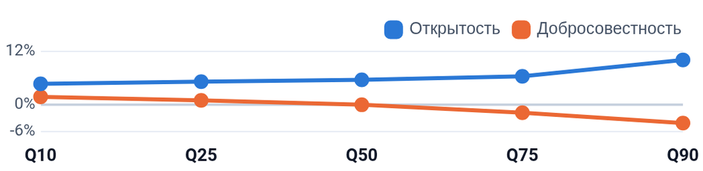

Что скрывает среднее: добросовестность +1.8% на q10 и −4.1% на q90 — усреднённая оценка ≈ 0; открытость 4.7% → 10.1%

— **Н6 проверяется напрямую**: отдача на q10…q90 оценивается и сравнивается — карта отдачи, а не тест на нелинейность

— **Робастность**: без предпосылки нормальности, устойчивость к выбросам и гетероскедастичности

Параметрический бутстрап — 1 000 реплик

Проверка того, что групповые коэффициенты навыков (случайные наклоны) **не случайны**

— Для каждого группового эффекта — бутстрап-доверительный интервал; для различий между группами — **поправки Холма и max-T** на множественные сравнения

— Случайные коэффициенты в смешанных моделях обычно приводятся без интервалов; здесь достоверность каждого проверена явно — **редко практикуемый стандарт**

— Именно это отделяет содержательную неоднородность от шума: слайды о неоднородности показывают только то, что прошло проверку

01

Результаты · Этап 1

Формальная занятость и её качество

ЗанятостьНеоднородностьХарактер трудаИнтерпретация

этап 1 из 3

Результаты · Этап 1Формальная занятостьПроверяет Н1

## Занятость: добросовестность и экстраверсия

[interactive chart not shown]

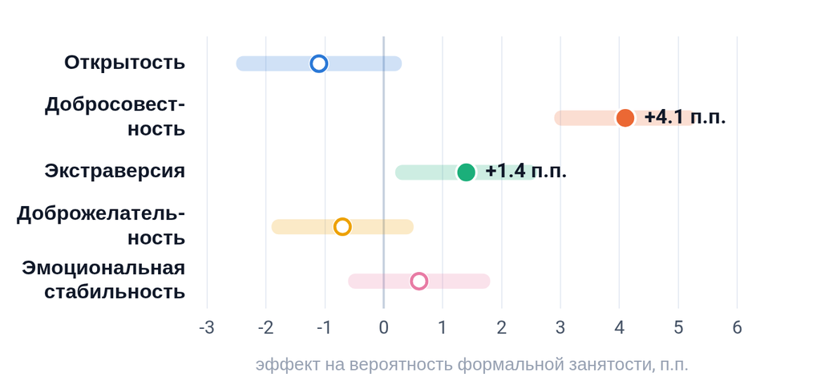

значимый эффект (p < 0.05) незначимый полоса — 95% ДИ · наведите курсор

+4.1 п.п.

**Добросовестность** (p < 0.001) — самодисциплина как «сигнал готовности к работе»

+1.4 п.п.

**Экстраверсия** (p < 0.05) — коммуникация и доступ к социальным сетям

Контекст

высшее образование +23.5 п.п. · текущая учёба −13.5 п.п. · верхний квинтиль дохода семьи +3.9 п.п.

Смешанная модель со случайными константами (индивид, регион, возраст) · N = 5 981 · R²<sub>cond</sub> = 0.61 · контроль: пол, образование, учёба, поселение, доход ДХ · табл. 4.1

**Результат (Н1):** навыки положительно связаны с вероятностью формальной занятости — значимы добросовестность и экстраверсия; эффекты сохраняются при контроле образования, учёбы и дохода семьи.

Результаты · Этап 1НеоднородностьПроверяет Н2

## Кому навыки помогают больше?

Черта

Группировка

[interactive chart not shown]

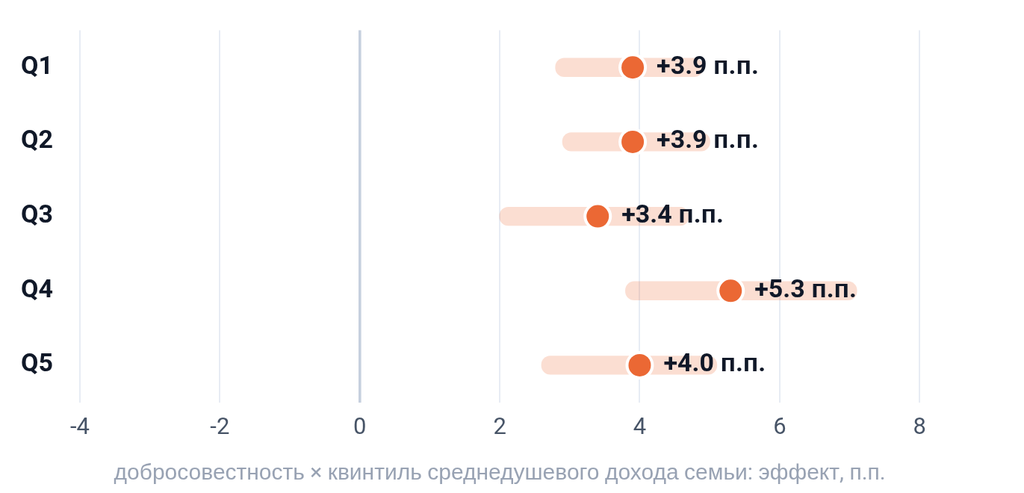

Эффект на вероятность формальной занятости, п.п.; полосы — 90% бутстрап-ДИ (1 000 реплик). Доход семьи — лагированный квинтиль среднедушевого дохода ДХ. Табл. 4.3–4.5.

Ключевые паттерны

— Богатство семьи **усиливает** преимущества добросовестности и экстраверсии (пик в Q4)

— Добросовестность: **мужчины +5.2** против **женщины +2.9 п.п.**

— Экстраверсия значима **только для женщин** (+2.0 п.п.)

— Экстраверсия продуктивнее при **низком образовании**; добросовестность усиливает преимущества высшего

**Результат (Н2):** эффект навыков модерируется богатством семьи, образованием и полом — навыки действуют не в социальном вакууме

Результаты · Этап 1Качество занятостиПроверяет Н3 · Н4

## Открытость: характер труда и профессиональное соответствие

Высококвалифицированный умственный труд

+3.6 п.п.

p < 0.01

Открытость повышает вероятность занятости в группах 1–3 МСКЗ-08 (руководители, специалисты). Механизм — когнитивная гибкость и склонность к нерутинным задачам.

N = 2 401 занятых · верхний квинтиль дохода семьи: +5.1 п.п. · прочие черты незначимы · табл. 4.6

Избыточное образование (только высшее)

−3.4 п.п.

p < 0.1

Среди выпускников вузов открытость снижает риск занятости ниже полученной квалификации — поддерживает конвертацию диплома в соответствующую должность.

N = 924 занятых с высшим образованием · избыточно образованы ≈ 21% занятой молодежи с ВО · табл. 4.8

**Результат (Н3, Н4):** открытость повышает вероятность занятости умственным трудом и снижает риск избыточного образования — рыночная ценность навыков меняется с показателем занятости; навыки снижают риск неэффективного использования человеческого капитала.

Результаты · Этап 1Интерпретация

## Как навыки конвертируются в занятость

**Навыки — каналы, через которые человеческий капитал конвертируется в результаты.** Ниже — теоретически ожидаемые механизмы этой конвертации: интерпретация оценок, согласованная с теорией, а не их прямая эмпирическая проверка.

Выберите фактор

Черта / фактор

**Добросовестность** — самодисциплина, упорство, доведение начатого до конца

→

Ожидаемый механизм

Саморегуляция поиска работы: метакогнитивная подготовка — резюме, интервью, соответствие институциональным «правилам игры»

→

Результат на рынке труда

Выше вероятность найма (+4.1 п.п.): работодатель читает черту как **сигнал готовности к работе** и снижает воспринимаемый риск

Источники: Almlund et al., 2011 · Roberts et al., 2007 · Turban et al., 2009

Этап 1Вывод

Занятость управляется двумя разными каналами — саморегуляцией (добросовестность) и социальным капиталом (экстраверсия), а их сила задаётся стартовыми условиями: комплементарность для ресурсных групп, компенсация — для остальных.

02

Результаты · Этап 2

Экономическая отдача: заработная плата

Квантильная отдачаРоль образованияЖизненный циклИнтерпретация

этап 2 из 3

Результаты · Этап 2Заработная платаПроверяет Н5 · Н6

## Отдача от навыков неоднородна по распределению зарплаты

Черта

[interactive chart not shown]

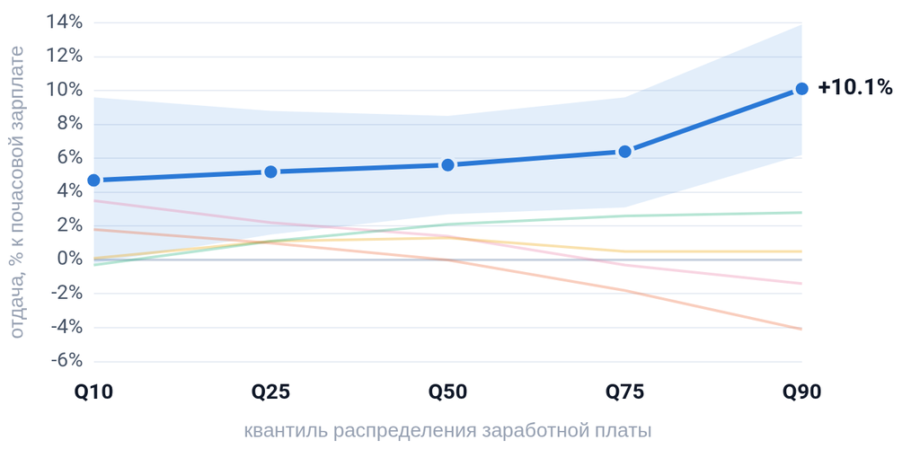

Квантильные смешанные модели (LQMM) с IPW · N = 2 661 (2 161 чел.) · заливка — 95% ДИ выбранной черты · закрашенные точки: p < 0.1 (точное p — при наведении) · табл. 5.1–5.2

4.7→10.1%

**Открытость**: единственная черта, значимая по всему распределению; отдача монотонно растёт к q90

−4.1%

**Добросовестность** — штраф в верхнем сегменте (q90); +1.0% на q25

до +2.8%

**Экстраверсия** — умеренный эффект в верхней половине (p < 0.1)

**Результат (Н5, Н6):** навыки связаны с зарплатой — открытость по всему распределению; отдача варьирует по квантилям, усреднённые модели скрывают эту динамику

Результаты · Этап 2Механизмы отдачиПроверяет Н7 · Н8 · Н9

## Образование опосредует отдачу, но не поглощает её

Открытость: отдача до и после учёта образования

[interactive chart not shown]

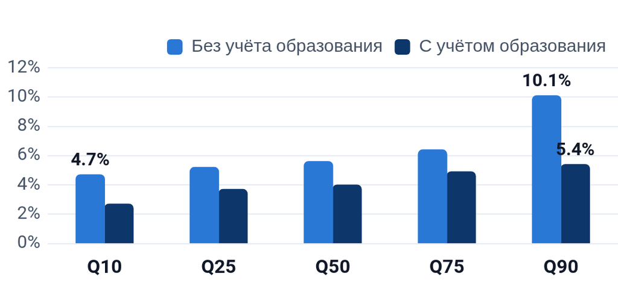

Связь ослабевает (премия за диплом: ВО +24…33%), но остаётся значимой на q25–q90 → прямой + опосредованный каналы

Медианная отдача по возрастным группам

[interactive chart not shown]

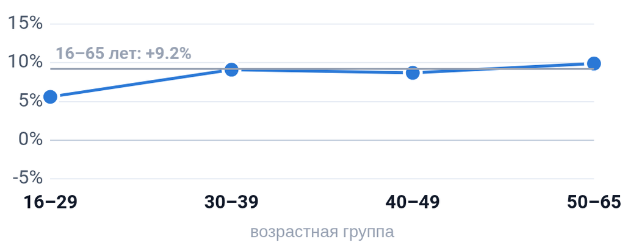

Открытость: 5.6% у молодежи → ≈ 9% в старших группах; эмоциональная стабильность приобретает значимость после 30 лет · табл. 5.3

**Результат (Н7, Н8, Н9):** часть отдачи «включена» в премию за диплом, но после учёта образования связь сохраняется; отдача различается по образованию и этапу жизненного цикла — навыки как самостоятельный канал там, где формальное образование играет меньшую роль.

Результаты · Этап 2Интерпретация

## Почему отдача растёт с уровнем оплаты труда

**Навыки — каналы, через которые человеческий капитал конвертируется в результаты.** Ниже — теоретически ожидаемые механизмы этой конвертации: интерпретация оценок, согласованная с теорией, а не их прямая эмпирическая проверка.

Выберите фактор

Черта / фактор

**Открытость** — когнитивная гибкость, адаптивность, автономия

→

Ожидаемый механизм

Премия за нерутинность: чем выше сегмент оплаты, тем больше труд состоит из нерутинных и автономных задач

→

Паттерн вознаграждения

Монотонный рост отдачи 4.7% → 10.1% — самый продуктивный навык молодежи на рынке труда

Источники: Almlund et al., 2011 · Borghans et al., 2008 · Collischon, 2019 · Edin et al., 2022

Этап 2Вывод

Механизмы вознаграждения навыков не универсальны — они зависят от позиции работника в структуре оплаты труда и от того, насколько труд нерутинный; универсального коэффициента отдачи не существует.

03

Результаты · Этап 3

Субъективное качество занятости

Общая удовлетворенностьКвинтили зарплатыКомпонентыИнтерпретация

этап 3 из 3

Результаты · Этап 3Субъективное качество занятостиПроверяет Н10 · Н11

## Удовлетворенность работой: не только зарплата

[interactive chart not shown]

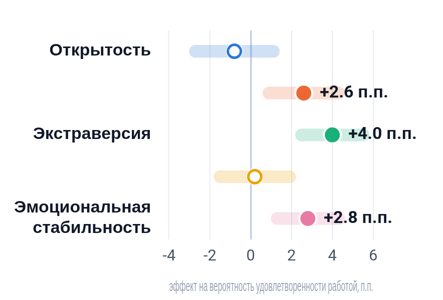

Эффект на вероятность удовлетворенности, п.п. (95% ДИ) · N = 2 924 · ≈ 70% молодых работников удовлетворены работой · табл. 6.2

По квинтилям заработной платы

[interactive chart not shown]

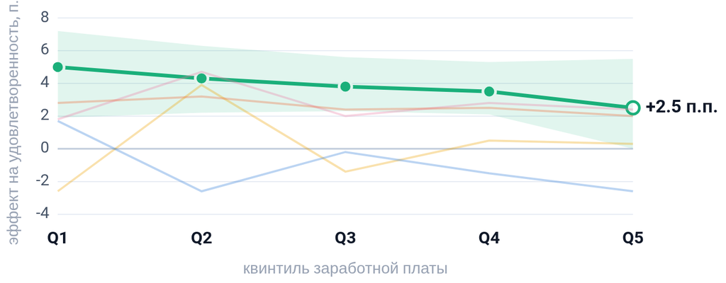

Случайные коэффициенты, 90% бутстрап-ДИ · Экстраверсия: 5.0 п.п. в Q1 → незначима в Q5 · табл. 6.3

**Результат (Н10, Н11):** значимы экстраверсия (+4.0), эмоциональная стабильность (+2.8) и добросовестность (+2.6 п.п.); связи варьируются по квинтилям зарплаты и относительно устойчивы по компонентам — условия труда, карьера, оплата (Н10–Н12).

Результаты · Этап 3Компоненты удовлетворенностиПроверяет Н12

## Связи устойчивы к разным аспектам удовлетворенности работой

[interactive chart not shown]

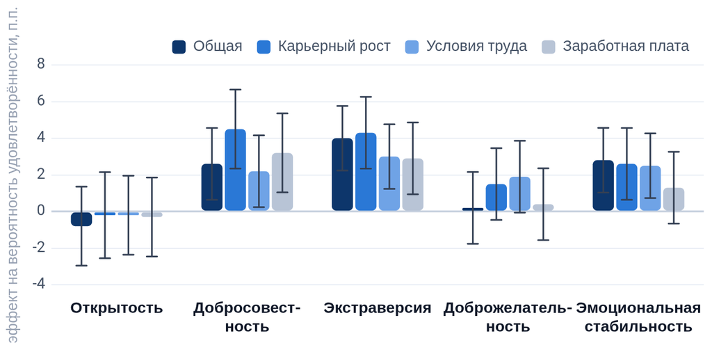

Эффект 1 СО навыка на вероятность удовлетворенности, п.п.; усы — 95% ДИ. Та же спецификация (зарплата, часы, случайные константы индивида, региона и профессии; IPW), четыре зависимые переменные · N = 2 924 · табл. 6.2 и 6.4

Д и Э

**значимы во всех трёх компонентах**; сильнее всего — для карьерного роста (+4.5 и +4.3 п.п.)

ЭС

карьера +2.6 и условия труда +2.5 п.п.; **с удовлетворенностью оплатой связи нет**

ДЖ

только условия труда: +1.9 п.п. (p < 0.1); открытость — ни в одном компоненте

Доля удовлетворённых: общая 70%, условия труда 69%, карьера 51%, оплата 38% (табл. 3.6)

**Результат (Н12):** те же черты — добросовестность, экстраверсия, эмоциональная стабильность — значимы для отдельных аспектов удовлетворенности; результат этапа 3 не зависит от того, какой именно аспект работы оценивает молодой работник.

Результаты · Этап 3Интерпретация

## Почему личность формирует восприятие работы

**Навыки — каналы, через которые человеческий капитал конвертируется в результаты.** Ниже — теоретически ожидаемые механизмы этой конвертации: интерпретация оценок, согласованная с теорией, а не их прямая эмпирическая проверка.

Выберите фактор

Черта / фактор

**Экстраверсия** — позитивный аффект, социальные связи, проактивность

→

Ожидаемый механизм

Три механизма: базовый положительный аффект; прочные межличностные связи в коллективе; проактивный подбор «своей» работы

→

Эффект на удовлетворенность

+4.0 п.п. к удовлетворенности; эффект **компенсаторный**: сильнее всего в низкооплачиваемом сегменте (5.0 п.п. в Q1)

Источники: Judge et al., 2002 · Furnham & Zacherl, 1986 · Seibert & Kraimer, 2001

Этап 3Вывод

Личность влияет на восприятие работы напрямую (аффект, стрессоустойчивость, мотивация) и во взаимодействии с зарплатой — субъективное качество занятости не сводимо ни к психологическим, ни к экономическим факторам по отдельности.

Вклад исследования

## Научная новизна

Впервые на российских данных показано, что некогнитивные навыки — **самостоятельный и действующий независимо от формального образования** фактор успеха молодежи на рынке трудазначимый механизм повышения индивидуальной продуктивности молодежи в сфере занятости

Влияние навыков носит **систематически неоднородный характер** в зависимости от предопределённых условий: стартового социально-экономического положения семьи, усиливающего кумулятивные преимущества, уровня образования и полапоказано, для каких групп молодежи и при каких условиях навыки особенно важны, — и методологическая необходимость дистанцироваться от усреднённой оценки по всей выборке

Впервые в российской экономической литературе оценена **неоднородная отдача от навыков на разных участках распределения заработной платы** молодежив отличие от усреднённых лог-линейных эффектов: одни и те же черты по-разному вознаграждаются при низкой, средней и высокой оплате — отдача зависит от позиции работника в структуре оплаты труда

Обосновано, что часть отдачи **опосредуется формальным образованием**, но вклад навыков к нему не сводится и является независимымотдача различается по уровням образования и полу и меняется за пределами молодежного возраста — новая интерпретация комплементарности и компенсаторной роли навыков в структуре человеческого капитала

Анализ расширен на **субъективное восприятие качества занятости**: значение экономических стимулов по мере роста заработной платы нелинейно, а навыки — канал мотивации к труду, влияющий на удовлетворенность работойвпервые на российских данных; идентифицирована неоднородность механизмов связи навыков с удовлетворенностью трудом через заработную плату

Вклад исследования

## Значимость результатов

Теоретическая

Эффекты навыков принципиально неоднородны: это **контекстно-зависимый механизм**, опосредованный исходными условиями и структурами неравенства. Значение навыков определяется не только их наличием, но и условиями конвертации.

Практическая

Основа для **таргетирования молодежной политики занятости**: какие навыки, для каких групп и на каком этапе снижают риски безработицы, избыточного образования и неудовлетворенности работой.

Методологическая

Апробация **линейных и квантильных смешанных моделей** (+ IPW, бутстрап) для панельных данных: многоуровневая гетерогенность и проверка гипотез за пределами среднего значения.

Апробация

## Публикации и доклады

5 статей в рецензируемых журналах

**Avanesian G., Rozhkova K.** (2025) The effect of non-cognitive skills on academic performance… // *International Journal of Educational Research*Q1 · список А ВШЭ

**Avanesian G.** (2025) Do Non-Cognitive Skills Produce Heterogeneous Returns Across Different Wage Levels…? // *Economies*Q2 · список С

**Avanesian G. et al.** (2024) How Far Are NEET Youth Falling Behind in Their Non-Cognitive Skills? // *Economies*Q2 · список С

**Аванесян К.А. и др.** (2022) Можно ли улучшить успеваемость школьников… инвестируя в некогнитивные навыки? // *Вопросы образования*Q2 · список B

**Avanesian G., Shipitko O., Borovskaya M.** Beyond Wages: The Role of Non-Cognitive Skills in Job Satisfaction of Young Workers // *Journal for Labour Market Research*принята в печать

Избранные выступления на конференциях

Int. Symposium on Human Capital & Labor Markets — **Пекин, 2025**

Society for the Advancement of Behavioral Economics — **Тренто, 2025**

Ясинская международная научная конференция, НИУ ВШЭ — **Москва, 2025 и 2022**

Международная конференция исследователей высшего образования, НИУ ВШЭ — **Москва, 2023**

</>

Воспроизводимое исследование

Quarto + R: код, данные и протокол всех расчётов (включая эту презентацию) открыты — **github.com/karavan88/Thesis**

Для сравнения: в ведущих экономических журналах воспроизвести удаётся лишь 14–49% статей (Gertler et al., 2018, *Nature*; Chang, Li, 2022)

Заключение

## Значение навыков зависит от условий трудового старта

Некогнитивные навыки — *социально встроенные ресурсы*: их ценность определяется не только наличием, но и условиями, в которых они конвертируются в результаты на рынке труда

Что это значит для политики

Результаты показывают: меры по развитию некогнитивных навыков молодежи могут выливаться в **более устойчивые результаты на рынке труда** — по четырём измерениям, изученным в работе:

занятостьпрофессиональное соответствиезаработная платаудовлетворенность работой

Дальнейшие исследования

По мере накопления волн РМЭЗ с измерением «Большой пятёрки» — **лонгитюдный дизайн**: динамика навыков и результатов у одних и тех же людей. Он позволит, в том числе, **контролировать обратную причинность** и перейти от условных связей к более сильным утверждениям о причинности.

Ограничения исследования и направления будущих работ подробнее — в материалах для дискуссии.

Спасибо за внимание!

Аванесян Карен Алексеевич

«Влияние некогнитивных навыков на характеристики занятости молодежи»

A

Приложение

Материалы для дискуссии

1 · Итоги и перспективы2 · Методология3 · Инструментарий4 · Чувствительность5 · Изменчивость навыков6 · Регрессионные таблицы

приложение

01

Дискуссия · раздел 1 из 6

Итоги и перспективы

Что следует из результатов для политики, где границы выводов и куда двигаться дальше

1Что развивать: компетенции вместо черт личности

2Ограничения исследования

3Направления будущих исследований

Дискуссия · итоги и перспективыГосударственное регулирование

## Что практически следует из результатов?

Вопрос

Какие конкретные меры следуют из результатов — что именно и у кого развивать?Ответ — следствие из оценок диссертации, а не результат оценки программ: эффективность конкретных мер в работе не тестировалась.

Направления развития — из результатов диссертации

**Из добросовестности** (занятость во всех группах, удовлетворённость): планирование, тайм-менеджмент, доведение задач; систематический поиск работы — резюме, отклики, подготовка к интервью

**Из экстраверсии** (вход на рынок труда, удовлетворённость низкооплачиваемых): коммуникация, самопрезентация, нетворкинг, работа в команде

**Из открытости** (отдача растёт с оплатой, меньше избыточного образования): умение учиться, адаптивность к нерутинным задачам, карьерная навигация

**Из эмоциональной стабильности** (удовлетворённость, удержание занятости после 30): управление стрессом, устойчивость к неудачам в поиске работы

Согласуется с рамкой социально-эмоциональных навыков ОЭСР (SSES); РКИ программ «мягких» навыков: Adhvaryu et al., 2018; Groh et al., 2016

Объект — компетенции, а не черты

В экономическом смысле черты — навыки: продуктивны, развиваемы, социально обусловлены (Green, 2013; Cunha et al., 2010). Но факторы «Большой пятёрки» — широкие диспозиции с высокой ранговой устойчивостью у взрослых (Roberts & DelVecchio, 2000; Cobb-Clark & Schurer, 2012) → развивать поведенческие компетенции, производные от черт (Heckman & Kautz, 2012)

Кому и когда

Приоритет — молодежь на входе: без высшего образования и обучающиеся (компенсация), низкооплачиваемые (экстраверсия). Наивысшая отдача — у ранних программ, но чувствительный период для некогнитивных навыков длиннее (Cunha et al., 2010)

Не проверялось: эффективность конкретных программ — оценены связи навыков с результатами, а не эффект вмешательств

Дискуссия · итоги и перспективыГраницы выводов

## Ограничения исследования

Выборка РМЭЗ

Смещена в сторону низкодоходных респондентов → оценки могут не отражать связи в высокодоходных группах молодежи

Инструмент измерения

Сокращённая международная шкала «Большой пятёрки» (15 пунктов, α 0.45–0.63): ограниченная чувствительность; ошибка измерения ослабляет оценки к нулю

Нет измерения когнитивных способностей

Коэффициент открытости (r с интеллектом ≈ 0.3) — верхняя граница «чистого» эффекта; после учёта образования отдача 4.7–10.1% → 2.7–5.4%, но сохраняется

Самоотчётность и пропуски

Социально одобряемые ответы; пропуски в доходах и в модуле навыков (2.3% молодежи) → взвешивание, аккуратная интерпретация репрезентативности

Оценки — **условные связи**, очищенные от основных смещений (стартовые условия, многоуровневая гетерогенность, самоотбор), но не каузальные эффекты: обратная причинность не устранена.

Дискуссия · итоги и перспективыОт условных связей к идентификации

## Направления будущих исследований

**Каузальная идентификация:** внутрисемейный (сиблинговый) дизайн по идентификаторам домохозяйств РМЭЗ — уже в работе автора (доклад SABE-2025); новые волны с повторным измерением навыков

**Когнитивные способности как контроль:** панель «Траектории в образовании и профессии» (PISA + «Большая пятёрка» для одной когорты) — уточнение «чистого» эффекта открытости

**Структурное моделирование каналов:** декомпозиция прямых и косвенных (через профессию и образование) эффектов — медиационные модели (Imai et al., 2010; Heckman & Pinto, 2015); вспомогательные проверки показали, что коэффициенты меняются при добавлении профессии и образования, но их долю канал не измеряет

**Изменчивость навыков и нелинейность:** лонгитюдный дизайн за пределами 4-летнего окна; квантильные и немонотонные зависимости; роль вузов в развитии компетенций

02

Дискуссия · раздел 2 из 6

Методология исследования

Идентификация, данные и теоретическая рамка

1Что оценивается и почему условные связи, а не каузальные эффекты?

2Пропущенные значения, импутация стажа и веса IPW: что сделано с данными?

3Теоретические основания гипотез

4Почему именно такие группирующие переменные и разбиения?

5Что меняет отсутствие измерения когнитивных способностей?

6Что означает самостоятельный вклад навыков при учёте образования и опыта?

7Мультиколлинеарность и гетероскедастичность моделей глав 4 и 6

Дискуссия · методологияИдентификация · 1/2

## Что оценивается — и почему не применены стандартные методы идентификации

Что оценено

Условные связи: изменение вероятности результата на 1 СО навыка при контроле стартовых условий, образования, региона и ненаблюдаемой гетерогенности индивида, региона и возраста — с поправкой на отбор в занятость (IPW) и с бутстрап-интервалами для групповых различий.Вопрос: источники эндогенности навыков описаны — почему не применён ни один из стандартных методов: инструментальные переменные, fixed effects, PSM, коррекция Хекмана? Ниже — по одному ответу на метод.

Инструментальные переменные

нужна переменная, влияющая на черты, но не на занятость: черты родителей и детские измерения в РМЭЗ отсутствуют, региональные факторы нарушают ограничение исключения → валидного инструмента нет

Fixed effects → случайные эффекты

у 98% респондентов обеих волн ответы 2019 г. на 15 пунктов совпадают с 2016 г. — FE устранили бы саму переменную. Отсюда случайные эффекты (индивид · регион · возраст): межиндивидуальная вариация сохранена, гетерогенность — через случайные наклоны

PSM и взвешивание (IPW)

оба метода — про **отбор в занятость по наблюдаемым**, а не про эндогенность черт. В работе применено IPW: те же оценки склонности (propensity score), но без потери «несопоставленных» наблюдений; PSM дал бы ту же логику идентификации на меньшей выборке

Коррекция Хекмана

модель отбора, не инструмент: корректирует наблюдаемость зарплаты только у занятых. Требует ограничения исключения — переменной, влияющей на занятость, но не на зарплату; убедительной в РМЭЗ нет, идентификация держалась бы на функциональной форме. Отбор учтён через IPW

Квазиэксперименты и факторные модели (Heckman–Stixrud–Urzua) требуют экзогенных шоков к личности или нескольких измерений — в данных есть один самоотчёт. **Общее у всех методов: каузальность — свойство дизайна, а не оценщика** → следующий слайд.

Дискуссия · методологияИдентификация · 2/2

## Каузальность — функция дизайна, а не метода: что сделано и что даст лонгитюд

Тезис

Ни один метод анализа не обеспечивает каузальность сам по себе: она должна быть заложена в дизайн — экзогенная вариация или измерение причины до следствия у одних и тех же людей.Оценщик может снять конкретные смещения при явных допущениях, но не превращает наблюдательные данные в эксперимент. Поэтому результаты интерпретируются как условные связи.

Что сделано вместо: последовательное снижение смещений

— **Стартовые условия** измерены до выхода на рынок труда (доход семьи в 15 лет) и включены как модераторы

— **Ненаблюдаемая гетерогенность**: случайные константы индивида, региона, возраста

— **Самоотбор в занятость**: взвешивание обратной вероятности в главах 4–6

— **Ложная значимость** групповых различий: бутстрап 1 000 реплик + поправки Холма и max-T

— **Чувствительность** к определению занятости, составу выборки, контролям и спецификации — раздел 4

Дальше: лонгитюдный дизайн по мере накопления волн

— **Навыки до результата**: «Большая пятёрка» измерена в 2016 и 2019 гг.; новые волны дадут повторные измерения у тех же людей

— **Контроль обратной причинности**: лаговые и перекрёстно-лаговые модели, внутрииндивидуальная динамика навыков и занятости

Первый шаг уже сделан

Навыки **2016** → занятость **2019** у продолжающих респондентов (N = 1 794): Д **+2.6****, Э **+2.3**** п.п. — знак и значимость сохраняются

Снижает риск обратной причинности, но не заменяет идентификацию: экзогенной вариации навыков по-прежнему нет

Дискуссия · методологияДанные

## Пропущенные значения: правила обработки и их влияние на оценки

Вопрос

Как обрабатывались пропуски в зависимых и независимых переменных и могут ли они влиять на итоговые оценки?

[output not shown]

Что переоценено, а что только описано

**Переоценено (П4):** общая удовлетворённость без 30 наблюдений с пропуском ответа — Э +4.0, ЭС +2.7, Д +2.6 п.п. против +4.0, +2.8, +2.6 в табл. 6.2: идентично

**Проверено диагностикой (следующие два слайда):** импутация стажа — LOESS-кривые волн и доля пропусков по возрастам; веса IPW — распределение и ESS

**Описано, без переоценки:** навыки (2.3%), доход семьи (11), зарплата в гл. 6 — доля мала, применены содержательные правила, зафиксированные в открытом коде

Множественное восполнение не применялось: после подготовки данных регрессоры главы 4 пропусков не содержат

Дискуссия · методологияДиагностика данных · стаж

## Пропуски стажа и LOESS-импутация

Вопрос

Сколько пропусков стажа в молодежной выборке и как они восполнены?Стаж — контроль в уравнениях заработной платы и удовлетворённости (главы 5–6); в моделях занятости главы 4 не используется. Импутация: по тем, кто стаж указал, внутри волны строится гладкая кривая LOESS «стаж — возраст»; пропуск заменяется значением кривой для возраста респондента; там, где кривая уходит ниже нуля (15–18 лет), стаж = 0.

[interactive chart not shown]

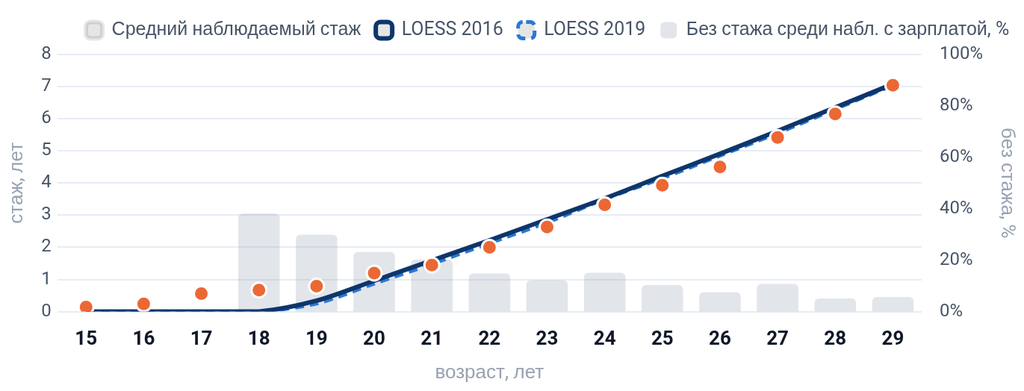

Точки — средний наблюдаемый стаж по возрастам; линии — LOESS-прогноз по волнам; столбцы — доля наблюдений **с зарплатой** (выборка гл. 5) без стажа в возрасте (правая ось).

304 / 2 662

наблюдений с зарплатой без данных о стаже (11%) — столько импутировано в модели гл. 5; в гл. 6 — 352 из 2 935 занятых (12%)

6% · 39%

доля без стажа среди формально (143 из 2 401) и неформально занятых (209 из 534): пропуски сосредоточены в неформальном сегменте

≈ 0.6 года

прирост LOESS-прогноза на год возраста после 19 лет; кривые волн 2016 и 2019 совпадают

Импутированный стаж — значение кривой для возраста респондента; в 15–18 лет кривая ниже нуля → стаж = 0 (в выборке гл. 5 таких 12 из 304)

Дискуссия · методологияДиагностика данных · веса

## Веса обратной вероятности занятости ведут себя хорошо

Вопрос

Не определяют ли результат несколько наблюдений с экстремальными весами IPW?Веса: логит вероятности занятости по возрасту, полу, образованию, региону и типу поселения внутри волны (WeightIt, оценка ATE); вес = 1/p для занятых и 1/(1−p) для незанятых; усечение на 10.

[interactive chart not shown]

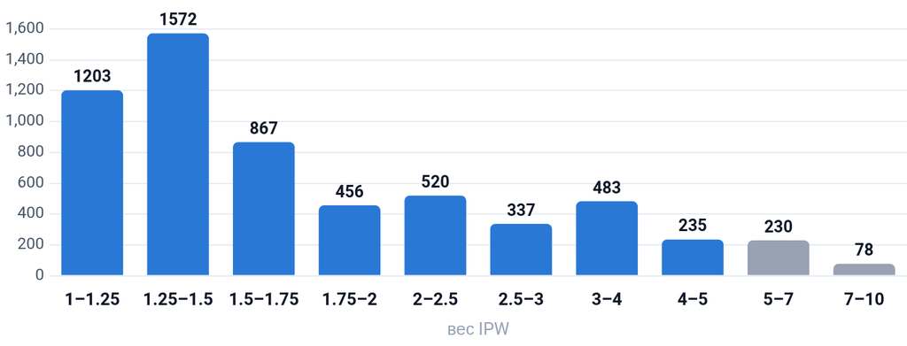

Распределение весов IPW, N = 5 981; над столбцами — число наблюдений.

1.54 · 2.10

медиана и среднее; минимум 1.03; 95% весов ≤ 5.1, 99% ≤ 7.9

20 из 5 981

наблюдений на пороге усечения 10 (0.3%) — экстремальных весов, способных определять результат, нет

ESS = 4 186

эффективный размер выборки — 70% номинального: взвешивание не «съедает» точность

Средний вес занятых 1.50, незанятых 2.68 — веса возвращают в оценку недопредставленные группы, а не отдельных людей

Дискуссия · методологияТеоретическая рамка

## Теоретические основания гипотез

Рамка

Н1–Н9 — теория человеческого капитала (Хекман): навыки — производительный актив, взаимодействующий с образованием и ресурсами семьи. Н10–Н12 — та же рамка (неденежная отдача) **плюс диспозиционный подход**: черты формируют восприятие работы напрямую.

| Гипотезы | Механизм | Предшествующие результаты |
| --- | --- | --- |
| H1, H5 — навыки повышают занятость и заработную плату | навыки как производительный актив; снижение издержек поиска и рисков найма; «стимулирующие» предпочтения в поведенческой модели заработной платы | Heckman, Stixrud & Urzua, 2006; Bowles, Gintis & Osborne, 2001; Uysal & Pohlmeier, 2011; Зудина, 2022 |
| H2, H9 — модерация стартовыми условиями, полом, образованием, жизненным циклом | динамическая комплементарность (ресурсы усиливают навыки) и компенсация (навыки замещают квалификации); гендерная асимметрия; employer learning | Cunha & Heckman, 2007; Heckman & Mosso, 2014; Akay & Yilmaz, 2023; Mueller & Plug, 2006; Altonji & Pierret, 2001 |
| H3, H4 — умственный труд, избыточное образование | профессиональная сортировка и соответствие «личность — работа» | Heckman et al., 2006; Filer, 1986; Esposito & Scicchitano, 2022 |
| H6 — отдача варьирует по распределению заработной платы | содержание задач и сортировка; институты оплаты — сжатие внизу, индивидуализация вверху; комплементарность с образованием | Lindqvist & Vestman, 2011; Edin et al., 2022; Collischon, 2020; Deming, 2017; Lemieux et al., 2009 |
| H7, H8 — опосредование образованием; прямой эффект | навыки могут влиять на получение образования и остаются самостоятельным фактором производительности | Heckman et al., 2006; Almlund et al., 2011; Рожкова & Рощин, 2021 |
| H10–H12 — удовлетворённость работой и её компоненты | неденежная отдача от человеческого капитала + диспозиционный подход (черты → аффект и восприятие работы); убывающая полезность заработка, ситуационная сила | Judge et al., 2002; Clark & Oswald, 1996; Meyer et al., 2010; Kang & Malvaso, 2023; Зудина, 2024 |

Интерпретация в гл. 4–6 — три механизма той же теории: комплементарность, компенсация, сортировка.

Дискуссия · методологияКомпоненты человеческого капитала

## Как связаны навыки и образование и что оценено отдельно?

| Вопрос | Что сделано в диссертации | Где в тексте |
| --- | --- | --- |
| Как связаны компоненты? | Взаимодополняемость навыков и образования. Образовательный и профессиональный каналы. | С. 6–8, 19 |
| Почему они коррелируют? | Общие условия формирования: родительские инвестиции, качество обучения, семейная среда. | С. 11 |
| Что оценивается отдельно? | Связь навыков с заработком при совместном учёте образования, опыта и других контролей. | С. 68–69 Ур. 5.1–5.2 |
| Что сохраняется после учёта образования? | Коэффициент открытости на медиане зарплаты: **0,056 без образования; 0,040 с образованием.** Оба статистически значимы. | С. 72, 74 Табл. 5.1–5.2 |
| Зависит ли связь от образования? | Случайные наклоны по образовательным группам в главе 4 и отдельные регрессии в главе 5. | С. 45, 70, 76 |
| Задел для дальнейших исследований | Учёт когнитивных способностей и причинное разделение компонентов человеческого капитала и каналов их влияния. | С. 11–12, 84 |

Раздельная статистическая оценка опирается на различия в навыках при сопоставимых образовании и опыте.

Дискуссия · методологияГруппирующие переменные

## Почему именно эти группы и разбиения

Вопрос

Не произвольны ли критерии группировок для оценки неоднородности — и содержательны ли результаты?Один критерий для всех: группы предопределены (ex-ante) относительно результата на рынке труда — могут модерировать эффект навыков, но не быть его следствием (в отличие от профессии или отрасли). Три модератора главы 4 — три измерения неравенства возможностей; в главе 6 зарплата — условие, в котором черта «работает», а не её результат.

| Группировка | Теоретическое основание — почему именно эта группа | Разбиение и почему такое |
| --- | --- | --- |
| Гл. 4 · Доход семьи в 15 лет | ресурсы семьи — прокси родительских инвестиций; комплементарность (Heckman, Mosso, 2014) | квинтили: без навязанной линейности; 894–1 766 набл. в группе |
| Гл. 4 · Образование | собственный формальный капитал: комплементарность / компенсация слабого сигнала | 4 уровня — структура российской системы образования |
| Гл. 4 · Пол | гендерная асимметрия вознаграждения черт (Mueller, Plug, 2006; Heineck, Anger, 2010) | два уровня |
| Гл. 5 · Квантили зарплаты | неоднородность отдачи по распределению: задачи, институты оплаты (Н6) | q10 / q25 / q50 / q75 / q90 — всё распределение |
| Гл. 5 · Возраст | жизненный цикл отдачи | 30–39, 40–49, 50–65 — десятилетия трудовой жизни |
| Гл. 6 · Квинтили оплаты | зарплата как условие: где материальных стимулов мало, черты весят больше (Н11) | квинтили почасовой оплаты; нелинейность установлена GAM |

Как оценивается модерация (если спросят): три отдельные модели М2–М4 — наклоны по одному фактору, два других в фиксированной части; общая модель с тремя перекрёстными факторами (63 параметра ковариаций) вырождается; достоверность различий — бутстрап 1 000 реплик, поправки Холма и max-T; паттерны устойчивы к смене определения занятости (r = 0.91).

Дискуссия · методологияОткрытость и когнитивные способности

## Что меняет отсутствие измерения когнитивных способностей?

Вопрос

В РМЭЗ нет измерения когнитивных способностей. Как это влияет на интерпретацию связи открытости с занятостью и зарплатой, если известно, что открытость коррелирует с интеллектом?Ключевое ограничение, названное первым в разделе 5.5; существенно оно для одной черты — открытости. Табл. 5.1–5.2, П5.

[interactive chart not shown]

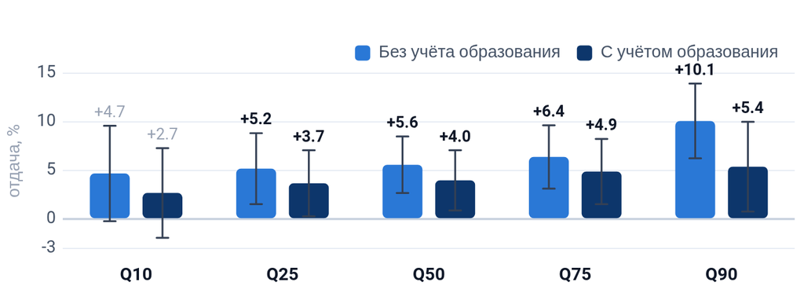

Отдача от открытости, % к почасовой оплате (LQMM с IPW, N = 2 661); усы — 95% ДИ. Образование и факт обучения — частичный, а не полный прокси когнитивных способностей.

≈ 0.3

корреляция открытости с интеллектом в метаанализах (сильнее для аспекта «интеллект» — два из трёх пунктов РМЭЗ); у остальных черт ≈ 0 или слабо отрицательна (Д)

смещение вверх

коэффициент открытости — **верхняя граница** «чистого» некогнитивного эффекта; выводы о Д и Э затронуты мало

**Контроль образования показывает:** эффект сохраняется (2.7–5.4%; на Q90 с профессией 5.0%**) — не сводится к способностям, сигнализируемым дипломом

**Чего он не разделяет:** когнитивную и некогнитивную компоненты внутри самой открытости — нужен прямой тест (панель ТрОП: PISA + «Большая пятёрка»)

Дискуссия · методологияНавыки, образование и опыт

## Что означает самостоятельный вклад навыков при учёте образования и опыта?

Вопрос

Навыки могут влиять на получение образования и накопление опыта. Что тогда измеряет коэффициент при навыках в модели, где образование и опыт уже учтены?С контролями — **прямая** связь, не проходящая через диплом и стаж; без них — **общая**, включающая канал образования. Разница — оценка канала при допущении, что нет других общих причин навыков и образования.

[interactive chart not shown]

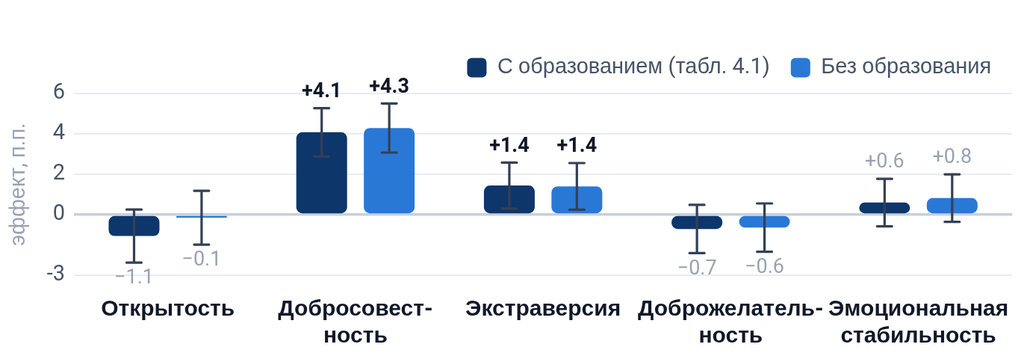

Эффект на вероятность формальной занятости, п.п.: модель М1 (табл. 4.1) с уровнем образования и без него, N = 5 981; усы — 95% ДИ. Скрипт edu_mediation.R (06_reviews/robustness).

4.08 → 4.29

**добросовестность**, занятость: почти весь эффект — прямой; через образование проходит ≈ 5%

−1.06 → −0.15

**открытость**, занятость: без контроля образования эффекта нет; отрицательный знак «с образованием» — открытые дольше учатся и позже выходят на рынок

10.1 → 5.4%

**открытость**, зарплата на Q90 (гл. 5): около половины общей отдачи связано с образованием; прямая отдача 2.7–5.4% значима на Q25–Q90

Навыки предопределены относительно образования (2016 → 2019 у продолжающих); корреляция шкал с высшим образованием ≤ 0.13, VIF 1.09–1.26 — вклад отделим; «доля через образование» — интерпретация, не тест медиации

Дискуссия · методологияДиагностика моделей · главы 4 и 6

## Мультиколлинеарность и гетероскедастичность: выводы устойчивы

Вопрос

Проверены ли модели глав 4 и 6 на мультиколлинеарность и гетероскедастичность?М1 табл. 4.1 и модель 2 табл. 6.2: VIF всех регрессоров; тест Бройша–Пагана на остатках; стандартные ошибки модели против кластерного бутстрапа по индивидам (200 реплик) и OLS-версии с кластер-робастными SE. Скрипт robustness_diagnostics.R.

| Черта | Оценка (SE модели) | SE бутстрап | SE OLS-кластер | Оценка (SE модели) | SE бутстрап | SE OLS-кластер |
| --- | --- | --- | --- | --- | --- | --- |
|  | Гл. 4 · формальная занятость, п.п. |  |  | Гл. 6 · удовлетворённость, п.п. |  |  |
| Открытость | −1.06 (0.67) | 0.78 | 0.68 | −0.76 (1.09) | 0.99 | 1.10 |
| Добросовестность | 4.08 (0.61)*** | 0.74 | 0.62 | 2.63 (1.00)*** | 1.09 | 1.02 |
| Экстраверсия | 1.44 (0.58)** | 0.65 | 0.58 | 3.99 (0.93)*** | 0.91 | 0.97 |
| Доброжелательность | −0.71 (0.61) | 0.63 | 0.63 | 0.15 (0.97) | 0.90 | 0.97 |
| Эмоц. стабильность | 0.60 (0.60) | 0.58 | 0.62 | 2.79 (0.94)*** | 0.97 | 0.95 |

Бутстрап: случайная выборка индивидов с возвращением, переоценка смешанной модели, SE = СО оценок по 200 репликам. OLS-кластер: та же спецификация без случайных эффектов, SE HC1 с кластером по индивиду.

Итог

— **Гетероскедастичность**: тест Бройша–Пагана не отвергает гомоскедастичность в гл. 4 (p = 0.29) и отвергает в гл. 6 (p = 0.003) — ожидаемо для линейной модели вероятности

— **Робастные SE отличаются от модельных не более чем на 20%** (бутстрап) и на 5% (кластер-OLS); все значимые эффекты — Д и Э в гл. 4, Э, ЭС и Д в гл. 6 — остаются значимыми

03

Дискуссия · раздел 3 из 6

Валидность инструментария

Надёжность шкал «Большой пятёрки» из трёх пунктов и её последствия для оценок

1Насколько надёжны шкалы РМЭЗ: психометрика инструмента

2Почему α 0.45–0.63 — норма для трёх пунктов: α как функция числа пунктов

3Международные сопоставления: западные и незападные обследования

4Что говорит методическая литература о коротких шкалах

5Ошибка измерения: консервативность оценок и сопоставимость черт

Дискуссия · инструментарийНадёжность шкал

## Насколько надёжны шкалы из трёх пунктов?

Вопрос

α Кронбаха четырёх из пяти шкал (0.45–0.52) не достигает конвенционального ориентира 0.7. Норма ли это для коротких шкал, что это значит для оценок и что проверено?

| Шкала | Пунктов | α Кронбаха | r межпунктовая | ω МакДональда |
| --- | --- | --- | --- | --- |
| Открытость | 3 | 0.52 | 0.27 | 0.58 |
| Добросовестность | 3 | 0.45 | 0.23 | 0.51 |
| Экстраверсия | 3 | 0.47 | 0.22 | 0.61 |
| Доброжелательность | 3 | 0.48 | 0.23 | 0.46 |
| Эмоциональная стабильность | 3 | 0.63 | 0.37 | 0.62 |

Табл. 3.1 диссертации; ω — однофакторная модель на выборке молодежи. 4-балльные ответные категории; шкалы стандартизованы (эффекты — на 1 СО)

Три ответа

**Норма.** Для 3 пунктов при r = 0.22–0.37 α механически ограничена 0.46–0.64; в 20+ обследованиях населения — тот же уровень (уточнения: проекция, таблицы, литература)

**Проверено переоценкой.** Шкалы без двух слабых обратных пунктов: Д +5.5 п.п. (было +4.1), Э +1.1 (p < 0.1); ω, поправка на ослабление; корреляции шкал −0.06…0.30, VIF 1.09–1.26 → слайд «Ошибка измерения»

Дискуссия · инструментарийНадёжность шкал

## Почему α 0.45–0.63 — норма для шкал из трёх пунктов

[interactive chart not shown]

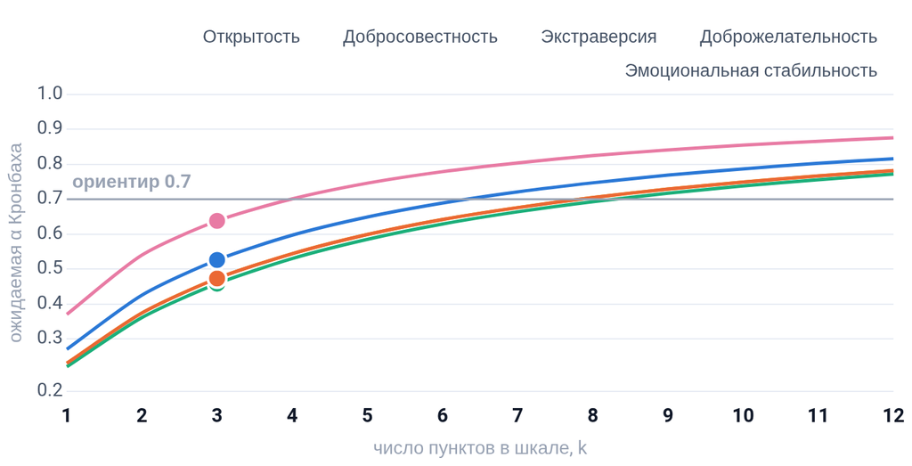

Проекция Спирмена–Брауна: ожидаемая α при том же качестве пунктов и разном их числе k; точки — фактические 3 пункта РМЭЗ. Пунктир — конвенциональный ориентир 0.7. Табл. П7.

α — функция числа пунктов

α = k·r̄ / (1 + (k − 1)·r̄)

— Те же пункты в шкале из **8** дали бы α 0.69–0.82, из **10** — 0.74–0.86

— Межпунктовые корреляции 0.22–0.37 — внутри диапазона 0.15–0.50, рекомендованного для коротких шкал (Clark & Watson, 1995)

— Разработчики STEP ожидали α 0.50–0.65 «ввиду широты конструктов и трёх пунктов» (Pierre et al., 2014)

— ω МакДональда 0.46–0.62; ретестовая надёжность аналогичных 3-пунктовых шкал 0.57–0.80 (Hahn et al., 2012)

Дискуссия · инструментарийНадёжность шкал · международные сопоставления

## α коротких шкал Big Five: западные обследования населения

| Обследование / инструмент | Пунктов на черту | О | Д | Э | ДЖ | ЭС / Н | Источник |
| --- | --- | --- | --- | --- | --- | --- | --- |
| РМЭЗ НИУ ВШЭ 2016/2019 (STEP), молодежь 15–29 | 3 | 0.52 | 0.45 | 0.47 | 0.48 | 0.63 | диссертация, табл. 3.1 |
| SOEP (Германия), BFI-S, основная выборка 2005 | 3 | 0.63 | 0.60 | 0.66 | 0.50 | 0.60 | Lang et al., 2011 |
| SOEP, BFI-S, претест 2004 (N ≈ 760) | 3 | 0.73 | 0.67 | 0.61 | 0.50 | 0.57 | Gerlitz & Schupp, 2005 |
| BFI-S, валидация (N = 598); ретест 18 мес. 0.57–0.80 | 3 | 0.58 | 0.60 | 0.76 | 0.44 | 0.66 | Hahn et al., 2012 |
| Швейцарская панель домохозяйств, BFI-15, пилот 2014 | 3 | 0.68 | 0.56 | 0.72 | 0.42 | 0.68 | Ryser, 2015 |
| BFI-10, 8 обследований Германии (N ≈ 60 000) | 2 | объединённая α 0.44 (0.18 ДЖ … 0.60 Э); ω 0.53 |  |  |  |  | Rammstedt et al., 2023 |
| TIPI (США) | 2 | 0.45 | 0.50 | 0.68 | 0.40 | 0.73 | Gosling et al., 2003 |
| BFI-2-XS (три выборки США) | 3 | диапазон 0.51–0.72; ретест 0.70–0.76 |  |  |  |  | Soto & John, 2017 |
| Mini-IPIP (США, N = 2 663) | 4 | 0.65 | 0.69 | 0.77 | 0.70 | 0.68 | Donnellan et al., 2006 |
| HILDA (Австралия), маркеры Saucier (N = 10 512) | 4–6 | 0.74 | 0.79 | 0.74 | 0.79 | 0.81 | Losoncz, 2009 |

Все значения — из первоисточников (табл. П8). HILDA достигает 0.74–0.81 за счёт 4–6 прилагательных-маркеров на черту, а не трёх пунктов. BHPS 2005 (BFI-15): «сопоставимо с SOEP, лучше TIPI» (Nandi & Nicoletti, 2014).

Дискуссия · инструментарийНадёжность шкал · международные сопоставления

## …и незападные: в Азии и в STEP α ниже, чем в РМЭЗ

| Обследование / инструмент | Пунктов на черту | О | Д | Э | ДЖ | ЭС / Н | Источник |
| --- | --- | --- | --- | --- | --- | --- | --- |
| РМЭЗ НИУ ВШЭ 2016/2019 (STEP), молодежь 15–29 | 3 | 0.52 | 0.45 | 0.47 | 0.48 | 0.63 | диссертация, табл. 3.1 |
| CFPS 2018 (Китай), 15 пунктов (N = 29 718) | 3 | 0.61 | 0.42 | 0.33 | 0.34 | 0.32 | Wu & Gu, 2020 |
| CFPS 2018 без 4 обратных пунктов | 2–3 | 0.61 | 0.45 | 0.56 | 0.52 | 0.52 | Wu & Gu, 2020 |
| IFLS-5 (Индонезия, 2014/15), BFI-15 (N = 11 188) | 3 | 0.46 | 0.39 | 0.43 | 0.36 | 0.33 | Botzet et al., 2021 |
| TVSEP (Таиланд, Вьетнам), BFI-S (N = 3 811) | 3 | 0.59 | 0.48 | 0.29 | 0.43 | 0.48 | Bühler et al., 2020 |
| STEP, волна 1, пять стран | 3 | 0.14 (Вьетнам) – 0.47 (Боливия); ожидалось 0.50–0.65 |  |  |  |  | Pierre et al., 2014 |
| STEP, 14 массивов (N = 40 584) | 3 | средняя α 0.49 (другие обследования LMIC 0.35; США, BFI-44 0.70) |  |  |  |  | Laajaj et al., 2019 |
| STEP, 15 стран (Шри-Ланка, Юньнань, Лаос, Вьетнам…) | 3 | «в целом в диапазоне 0.3–0.4» |  |  |  |  | Laajaj et al., 2018 |
| LEAPS (Пакистан), BFI-15, молодые взрослые | 3 | диапазон по шкалам 0.53–0.68 |  |  |  |  | Danon et al., 2023 |
| Япония: TIPI-J (панели JHPS/KHPS, JLPS) | 2 | α не приводится; r пар пунктов 0.22–0.59; ретест 0.64–0.86 |  |  |  |  | Oshio et al., 2012 |

Значения — из первоисточников (табл. П8). Обратные пункты снижают согласованность в CFPS и STEP (acquiescence): та же проблема двух пунктов РМЭЗ с низкой дискриминацией (табл. 3.1).

Дискуссия · инструментарийНадёжность шкал · сводка

## Средняя α по пяти шкалам: РМЭЗ — на уровне SOEP, выше STEP и азиатских панелей

[interactive chart not shown]

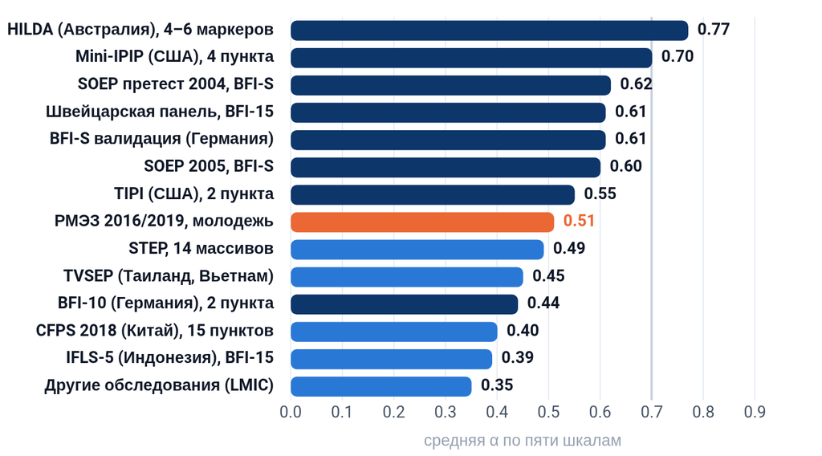

Что видно

— Все 3-пунктовые инструменты в обследованиях населения дают среднюю α **0.4–0.6**; ориентир 0.7 достигают только шкалы из 4–6 маркеров (HILDA) или 44 пунктов (BFI-44)

— В незападных выборках α систематически ниже: обратные пункты, согласие с утверждениями (acquiescence), эффекты интервьюера (Laajaj et al., 2019)

— РМЭЗ (0.51) — между SOEP (0.60) и STEP (0.49): типичный уровень для population-based обследования

западные незападные РМЭЗ

Средняя по пяти шкалам, где опубликованы все пять значений; STEP — средняя из Laajaj et al. (2019). Источники — табл. П8.

Дискуссия · инструментарийНадёжность шкал · методическая литература

## Для population-based inference низкая α коротких шкал — ожидаемая плата за широту конструкта

«Не существует священного уровня приемлемой α … меры с низкой (по конвенции) α могут быть вполне полезны»

Schmitt, 1996 · Psychological Assessment

Если шкала предназначена **для групповой статистики**, приоритет эффективности измерения над внутренней согласованностью приемлем

Ziegler, Kemper & Kruyen, 2014 · «Пять заблуждений о коротких шкалах»

Валидность личностных шкал предсказывается **ретестовой надёжностью**, а не внутренней согласованностью

McCrae, Kurtz, Yamagata & Terracciano, 2011 · PSPR

α «не отражает внутреннюю структуру теста» и имеет «очень ограниченную полезность»

Sijtsma, 2009 · Psychometrika

Для 2-пунктовых шкал BFI-10 α «непригодна как оценка надёжности»: пункты подобраны для широты, а не однородности

Rammstedt et al., 2013; Rammstedt, Roemer & Lechner, 2023

Команда STEP ожидала α 0.50–0.65 «из-за широты конструктов и малого числа (трёх) пунктов»; межпунктовые r 0.15–0.50 — норма для коротких шкал

Pierre et al., 2014 · World Bank; Clark & Watson, 1995

Короткие шкалы в обследованиях населения оптимизированы под **охват конструкта и низкую нагрузку на респондента**, а не под однородность пунктов; их пригодность для выводов о связях на уровне популяции определяется валидностью и ретестовой надёжностью, а не α (Gosling et al., 2003; Credé et al., 2012; Kruyen et al., 2013).

Дискуссия · инструментарийНадёжность шкал · последствия для оценок

## Ошибка измерения: оценки консервативны, ранжирование черт устойчиво

Вопрос

Влияет ли низкая внутренняя согласованность шкал на величину и значимость оценок и на сопоставимость эффектов разных черт?Главное свидетельство — фактическая переоценка модели занятости со шкалами без двух слабых обратных пунктов (столбец «Шкала без слабого пункта»); β/α — расчётная верхняя граница поправки на ослабление.

[output not shown]

β/α — поправка на ослабление (верхняя граница; регрессоры слабо коррелированы, VIF 1.09–1.26). Без слабого пункта: Д без «расслабляться, чем трудиться» (дискриминация 0.16), Э без «держать мнение при себе» (0.11). Табл. П9.

Что проверено и что из этого следует

— Направление смещения известно: ошибка измерения в регрессоре **смещает β к нулю** (Wooldridge, 2010) и снижает мощность, а не порождает ложноположительные выводы

— Наибольший эффект даёт шкала с **наименьшей α** (добросовестность): после поправки разрыв только растёт; перетекание между чертами ограничено (r шкал −0.06…0.30)

04

Дискуссия · раздел 4 из 6

Чувствительность результатов

Устойчивость ключевых эффектов к определению занятости, составу выборки и спецификации

1Определение занятости: формальная наёмная, любая, неформальная; кто в выборке

2Случайные наклоны при другом определении занятости

3Обучающаяся молодежь, состав семьи и возрастные группы

4Профессия как канал отдачи от навыков

5Что устойчиво, а что чувствительно к спецификации

Дискуссия · чувствительностьЧувствительность к определению занятости

## Устойчивы ли эффекты навыков к определению занятости? Да

Вопрос

Модели главы 4 объясняют *формальную наёмную* занятость. Изменятся ли эффекты, если считать занятостью любую работу — включая неформальную и самозанятость?Кто в выборке и что измеряет зависимая переменная: вся молодежь 15–29 лет (N = 5 981), включая обучающихся и неактивных; DV = 1 — работает по найму с официальным оформлением (39.6%), 0 — все остальные: неформально занятые (8.9%), самозанятые (0.7%, 41 набл.), безработные, обучающиеся, неактивные. Эффект — п.п. вероятности на 1 СО навыка. Табл. П1–П2.

[interactive chart not shown]

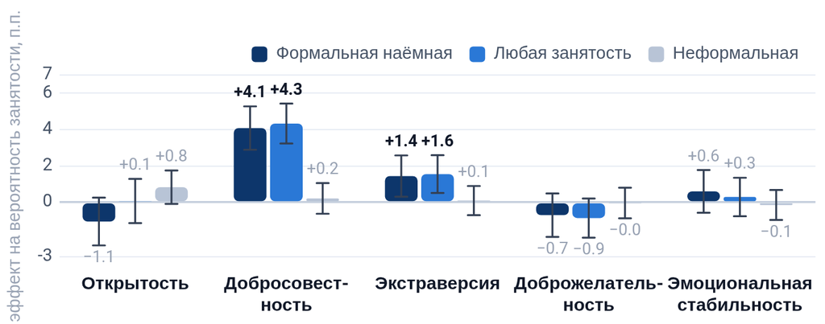

Та же спецификация (табл. 4.1), три зависимые переменные. Любая занятость = «работает» (j1, 49.1%), включая неформально занятых и самозанятых; неформальная — только они (8.9%).

+4.3 п.п.

**Добросовестность** при любой занятости (в диссертации +4.1); **экстраверсия** +1.6 (+1.4); разность коэффициентов незначима (p > 0.1)

≈ 0

Отдельная модель **неформальной занятости**: значимых эффектов навыков нет (О +0.8, p < 0.1); группа небольшая — мощность ограничена

r = 0.91

55 групповых коэффициентов при двух определениях занятости — паттерны неоднородности воспроизводятся (следующий слайд)

Зарплата (гл. 5) и удовлетворённость (гл. 6) оценены на всех занятых, включая неформально занятых (494 и 534 наблюдения) и самозанятых

Дискуссия · чувствительностьОпределение занятости и случайные наклоны

## Сохраняются ли паттерны неоднородности при любой занятости? Да

Вопрос

Неоднородность эффектов по доходу семьи, образованию и полу оценена для формальной занятости. Воспроизводятся ли групповые коэффициенты при любой занятости?Три модели со случайными наклонами (табл. 4.2) переоценены с зависимой переменной «любая занятость»; 55 групповых коэффициентов = 5 черт × 11 групп. Табл. П2.

[interactive chart not shown]

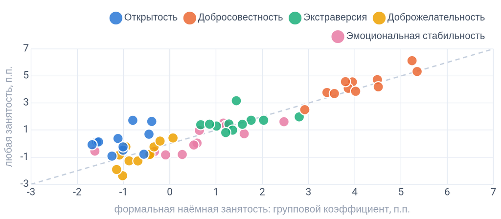

Каждая точка — **точечный** групповой коэффициент (фиксированный эффект + случайное отклонение группы), п.п.; пунктир — линия равенства. Сравниваются точечные оценки без их интервалов: r описывает воспроизводимость паттерна, а не формальный тест.

Корреляция точечных оценок r = 0.91

— Добросовестность по доходу семьи: пик в **Q4** в обоих определениях (5.3 / 5.3 п.п.)

— Добросовестность по полу: мужчины **5.2 → 6.1**, женщины **2.9 → 2.5** п.п.

— Экстраверсия по образованию: сильнее у молодежи без высшего образования в обоих определениях

Три модели оцениваются **раздельно** (по одному модератору), но два других модератора остаются в фиксированной части — наклоны условны по ним

Дискуссия · чувствительностьОбучающаяся молодежь

## Обучающаяся молодежь: различия в эффектах статистически не значимы

Вопрос

40% молодежи 15–29 лет продолжают обучение — не ослаблен ли у них эффект навыков и не искажает ли это оценки по всей выборке?Три проверки на той же спецификации (табл. 4.1): без обучающихся; 20–29 лет; модель с взаимодействиями «навык × обучается». Табл. П3.

[interactive chart not shown]

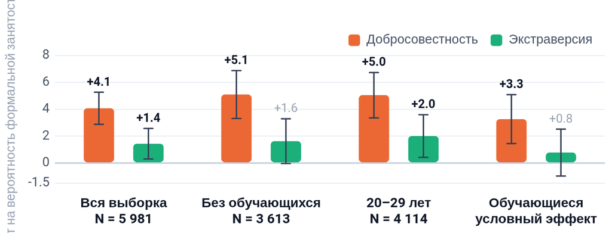

Эффект на вероятность формальной занятости, п.п.; усы — 95% ДИ. «Обучающиеся» — условный эффект из модели с взаимодействиями навык × обучается.

× обучается ≈ 0

взаимодействия: Д −1.3 (1.2), Э −1.1 (1.1) — **ни одно не значимо**: различить эффекты у обучающихся и остальных статистически нельзя

+5.1 п.п.

**Добросовестность** без обучающихся (по всей выборке +4.1); среди обучающихся сохраняется (+3.3, p < 0.01)

+1.6…+2.0

**Экстраверсия** без обучающихся / 20–29 лет; среди обучающихся точечная оценка ниже (+0.8) и незначима

В базовой модели обучение учтено: контроль «обучается» (−13.5 п.п.) + случайная константа по возрасту. Оценки по всей выборке не завышены; более высокие оценки у завершивших обучение — тенденция, не значимое различие

Дискуссия · чувствительностьСостав семьи и дополнительные контроли

## Меняет ли состав семьи оценки навыков? Нет — хотя сам он значим

Вопрос

СЭС семьи измерен доходом в 15 лет, а состав семьи есть только в модели зарплаты — почему его нет в моделях занятости и удовлетворенности и не использованы другие индикаторы РМЭЗ: иждивенцы, безработные в семье, удовлетворенность жизнью, субъективный статус?Логика ex-ante условий: контроли фиксируются до выхода на рынок труда либо не являются следствием результата. Для 15–19-летних брак и дети одновременны с решениями о занятости — риск «плохого контроля» (Angrist, Pischke, 2009). Табл. П3–П4.

[interactive chart not shown]

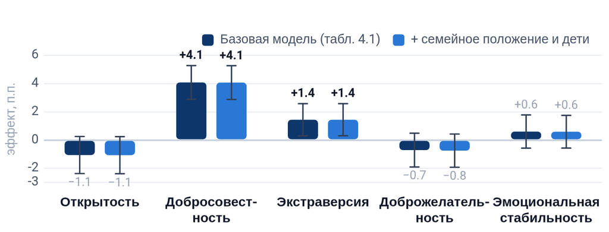

Эффект на вероятность формальной занятости, п.п.; усы — 95% ДИ. Модель табл. 4.1 без и с семейным положением и наличием детей (N = 5 981).

+5.9 / −5.3

п.п. — **брак** и **дети** сами значимы (p < 0.01), но оценки навыков не сдвигают: Д 4.07 против 4.08, Э 1.44 против 1.44

+4.0 · +2.8 · +2.7

**удовлетворенность работой** (гл. 6) с составом семьи: Э, ЭС, Д — как в табл. 6.2 (4.0 · 2.8 · 2.6)

Иждивенцы, безработные в семье, удовлетворенность жизнью и субъективный статус измерены в момент опроса и зависят от наличия работы — пост-результатные переменные; образование родителей для основной части молодежи недоступно — отсюда доход семьи в 15 лет как прокси

Дискуссия · чувствительностьМолодежь и старшие возрастные группы

## Отличается ли молодежь от старших возрастов? Наблюдаемые различия — и их интерпретация

Вопрос

Отличаются ли эффекты навыков на занятость молодежи от эффектов в старших возрастных группах?Та же модель занятости оценена для 30–39, 40–49 и 50–65 лет (без квинтиля дохода в 15 лет, недоступного для старших когорт); РМЭЗ 2016 и 2019. Табл. П6; заработная плата — табл. 5.3.

[interactive chart not shown]

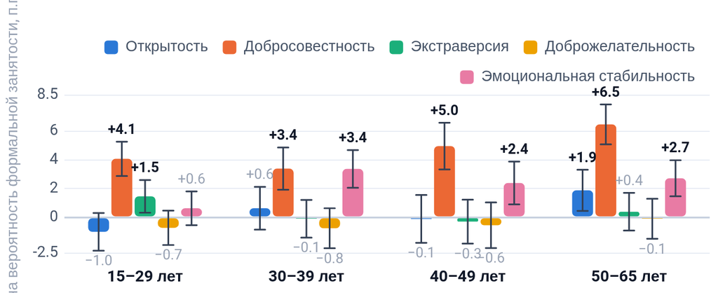

Эффект на вероятность формальной занятости, п.п.; усы — 95% ДИ.

Что наблюдается

**Экстраверсия** значима только у 15–29 (+1.5 п.п.); **эмоциональная стабильность** — только в 30+ (+2.4…+3.4); **добросовестность** — во всех возрастах (+3.4…+6.5); открытость — только в 50–65; доброжелательность — нигде. В зарплате отдача от открытости растёт с 5.6% на медиане у молодежи до 9–10% в старших группах (табл. 5.3)

Интерпретация

На входе, при слабых формальных сигналах, вознаграждаются черты поиска и социальных связей; для удержания занятости в зрелом возрасте — стрессоустойчивость и надёжность; в зарплате — накопление опыта и «обучение» работодателя. Сравниваются разные когорты в одних волнах, а не одни люди во времени

Дискуссия · чувствительностьПрофессия как канал отдачи от навыков

## Профессия как канал: что меняется в коэффициентах открытости и добросовестности

Вопрос

Опосредует ли профессия отдачу от навыков — и объясняет ли профессиональный отбор штраф за добросовестность на 90-м квантиле?Вспомогательная проверка: та же квантильная смешанная модель, что в табл. 5.1 (LQMM, случайный эффект индивида, веса IPW, бутстрап SE, 50 реплик), переоценена на подвыборке с известной профессией (N = 2 657 из 2 661): базовая, + дамми 9 групп МСКЗ-08, + профессия и образование. Сравнивать светлые столбцы между собой; тёмный — ориентир из табл. 5.1 на полной выборке. Табл. П5 (LQMM-версия).

[interactive chart not shown]

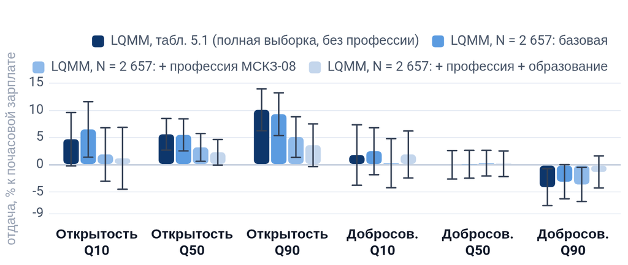

Отдача, % к почасовой оплате; усы — 95% ДИ. Тёмный столбец — LQMM табл. 5.1 (полная выборка); светлые — та же LQMM на подвыборке с профессией: базовая, + профессия, + профессия и образование. Расхождение тёмного и базового светлого — подвыборка и бутстрап SE.

9.3 → 5.1%

**Открытость на Q90**: с профессией коэффициент ниже на 4 п.п., остаётся значимым на 1%; с образованием — 3.6% (p < 0.1): часть связи идёт через профессиональную группу, часть — внутри неё

−3.1* → −3.6**

Почему профессии нет в основной модели

Профессия — одновременно канал и следствие черт («плохой контроль»: Filer, 1986; Nandi & Nicoletti, 2014): коэффициент с профессией — ни общий, ни прямой эффект без допущений медиации; доля канала не оценивается

Дискуссия · чувствительностьСводка

## Что устойчиво, а что чувствительно к спецификации

| Проверка (занятость, гл. 4, если не указано иное) | Д, п.п. | Э, п.п. | Итог |
| --- | --- | --- | --- |
| Базовая модель (табл. 4.1), N = 5 981 | +4.08 | +1.44 | — |
| Любая занятость (DV) | +4.33 | +1.55 | не меняет |
| Случайные наклоны при любой занятости | r = 0.91 по 55 точечным оценкам |  | паттерн тот же |
| + семейное положение, дети | +4.07 | +1.44 | не меняет |
| Без образования (общий эффект) | +4.29 | +1.40 | не меняет |
| Без обучающихся / 20–29 лет | +5.10 / +5.05 | +1.63 / +2.01 | выше; разница незначима |
| Навыки 2016 → занятость 2019 (N = 1 794) | +2.62 | +2.33 | знак и значимость те же |
| Шкалы без слабых обратных пунктов | +5.52 | +1.09* | Д выше; Э на 10% |
| Удовлетворённость (гл. 6): без пропусков / формальные / + семья | +2.6 / +2.6 / +2.7 | +4.0 / +4.3 / +4.0 | не меняет |
| Профессия в уравнении зарплаты, Q90 (гл. 5, LQMM) | О 9.3% → 5.1%, значима; Д −3.1* → −3.6**, с обр. −1.3 |  | О ниже; Д не объясняет |

Выделены значимые на 5%; * — 10%. Табл. П1–П5, П9; edu_mediation.csv; бутстрап + Холм/max-T для случайных коэффициентов — Приложение E диссертации.

Устойчиво

— **Добросовестность** → занятость: +4.1…+5.5 п.п. во всех спецификациях на полной выборке и подвыборках, p < 0.01; в лаговой подвыборке +2.6**

— Удовлетворённость: Э, ЭС, Д при любом наборе контролей и по компонентам; паттерны неоднородности — при смене DV

Чувствительно

— Штраф за **добросовестность на Q90** зарплаты: −4.1**; профессией не объясняется, исчезает с контролем образования (−1.3)

— **Экстраверсия среди обучающихся**: +0.8, незначима (различие с остальными тоже незначимо)

— **Открытость**: коэффициент — верхняя граница (нет когнитивных тестов); в занятости знак зависит от контроля образования

05

Дискуссия · раздел 5 из 6

Изменчивость навыков

Насколько устойчивы некогнитивные навыки во времени — проверка на полной возрастной панели РМЭЗ (все волны с модулем «Большой пятёрки»)

1Устойчивость во времени: ICC — межиндивидуальная и внутрииндивидуальная компоненты

2Возрастные различия и изменения внутри человека: декомпозиция Мундлака

3Средние внутрииндивидуальные изменения: кривые роста

4Хронология: когда изменения были наиболее выражены

5Динамика навыков по возрастным группам

ДискуссияИзменчивость навыков · ICC

## Насколько устойчивы навыки во времени?

Выборка

17 326 человек, 65 700 наблюденийПять обследований 2016–2024 годов. Возрастных ограничений нет, каждый участник наблюдается минимум дважды.

[figure not shown]

Между людьми (ICC)Внутри человека (1 − ICC)

32–36%

дисперсии приходится на внутрииндивидуальную остаточную компоненту

Большая часть вариации связана с устойчивыми различиями **между людьми**.

Изменения показателей **у одного человека** также существенны, но включают ошибку измерения.

Устойчивые различия между людьми сочетаются с изменением индивидуальных показателей.

Моделирование методом кривой роста. M0 — нулевая модель со случайной константой человека. ICC характеризует дисперсию наблюдаемых баллов.

ДискуссияИзменчивость навыков · Мундлак

## Возрастные различия и изменения внутри человека

Разложение

Возрастные различия между людьми и изменение у одного человекаВ модели Мундлака возраст разделён на средний возраст человека и отклонение от его среднего.

Внутри человека, βWМежду людьми, βB

[figure not shown]

SD 2016 на год возраста. Усы — 95% ДИ (CR2).

Два разных сравнения

**Между людьми:** различаются ли показатели у более старших и более молодых участников?  
**Внутри человека:** как меняется показатель того же участника со временем?

4 из 5 шкал

Оценки βW и βB статистически различаются. Для эмоциональной стабильности: **+0,016** внутри человека и **−0,008** между людьми.

Моделирование методом кривой роста. M2 — индивидуальные уровни и наклоны. Тест βW = βB: модельный Wald. 65 700 наблюдений.

ДискуссияИзменчивость навыков · Средняя динамика

## Средние внутрииндивидуальные изменения

Оценка

Среднее изменение показателя на дополнительный год возрастаУчитываются средний возраст, пол, образование и тип населённого пункта при первом наблюдении.

[figure not shown]

SD 2016 на год возраста. Усы — 95% ДИ (CR2).

+0,016

**Эмоциональная стабильность**  
SD за год возраста

−0,011

**Добросовестность**  
SD за год возраста

Это средние наклоны по всей панели. Они могут скрывать различия между возрастными группами и периодами.

Направление и величина изменений различаются между навыками. Возрастные группы рассматриваются отдельно.

Моделирование методом кривой роста. M3 — индивидуальные случайные уровни и наклоны, базовые контроли. 65 554 наблюдений / 17 279 человек.

ДискуссияИзменчивость навыков · Хронология

## Когда изменения были наиболее выражены?

Хронология

Самый сильный сдвиг между соседними обследованиями: 2019–2020Месяц и год фактического интервью определяют положение точек по горизонтали. Уровень 2016 года принят за ноль.

[figure not shown]

Изменение относительно 2016 года, SD. Усы — 95% ДИ (CR2).

+0,10

**Эмоциональная стабильность**  
SD между 2019 и 2020

−0,09

**Добросовестность**  
SD между 2019 и 2020

Интервью в феврале–августе 2020 отсутствуют. Модель не устанавливает март как дату изменения навыков и не выделяет отдельный эффект COVID.

ОткрытостьДобросовестностьЭкстраверсияДоброжелательностьЭмоциональная стабильность

Моделирование методом кривой роста. M4 — индикаторы обследований, индивидуальный линейный наклон, базовые контроли. 65 554 наблюдений.

ДискуссияИзменчивость навыков · Возрастные группы

## Динамика навыков по возрастным группам

Возраст

От подростковых возрастов до 75 лет и старшеГруппа определяется средним возрастом человека за период панели, а не возрастом в начале наблюдения.

[figure not shown]

Изменение в SD 2016 на год возраста. Единый масштаб по всем навыкам. Усы — 95% модельные ДИ.

**Добросовестность:** +0,044 SD/год в 20–24 года и −0,057 SD/год в группе 75+.

Моделирование методом кривой роста. M5 — взаимодействие возраста внутри человека с возрастной группой, базовые контроли. 65 554 наблюдений.

06

Дискуссия · раздел 6 из 6

Регрессионные таблицы

Полные таблицы диссертации по главам — для ответов на вопросы о конкретных коэффициентах; длинные таблицы прокручиваются

1Глава 4 — занятость, умственный труд, избыточное образование: табл. 4.1–4.8

2Глава 5 — заработная плата, квантильные смешанные модели: табл. 5.1–5.3

3Глава 6 — удовлетворённость работой и её компоненты: табл. 6.1–6.4

4Приложение E — бутстрап-ДИ и p-значения случайных коэффициентов: табл. 7.4–7.8

Регрессионные таблицы · гл. 4Таблица 4.1 · с. 48 диссертации

## Занятость: базовая модель с некогнитивными навыками

|  | Формальная занятость |
| --- | --- |
| Фиксированные эффекты |  |
| Константа | −0.445 (0.309) |
| Возраст | 0.031 (0.028) |
| Возраст² | 0.000 (0.001) |
| Пол: Мужской | −0.003 (0.011) |
| Обр: Среднее | 0.088*** (0.018) |
| Обр: Среднее проф | 0.141*** (0.018) |
| Обр: Высшее | 0.235*** (0.021) |
| В настоящее время обучается | −0.135*** (0.016) |
| Тип поселения: ПГТ | 0.015 (0.028) |
| Тип поселения: Город | 0.012 (0.022) |
| Тип поселения: Обл центр | 0.042 (0.030) |
| Среднедушевой доход ДХ: Q2 | 0.001 (0.016) |
| Среднедушевой доход ДХ: Q3 | 0.028. (0.016) |
| Среднедушевой доход ДХ: Q4 | 0.010 (0.018) |
| Среднедушевой доход ДХ: Q5 | 0.039* (0.018) |
| Открытость опыту | −0.011 (0.007) |
| Добросовестность | 0.041*** (0.006) |
| Экстраверсия | 0.014* (0.006) |
| Доброжелательность | −0.007 (0.006) |
| Эмоциональная стабильность | 0.006 (0.006) |
| Случайные эффекты |  |
| Var(u0): Возраст | 0.002 (1.3%) |
| Var(u0): Индивидуальный ID | 0.054 (35.0%) |
| Var(u0): Регион | 0.007 (4.2%) |
| Var(Residual) | 0.092 (59.5%) |
| Качество модели |  |
| RMSE | 0.250 |
| R2 marginal | 0.348 |
| R2 conditional | 0.613 |
| N | 5981 |

Примечание: коэффициенты приведены со стандартными ошибками в скобках; *** p < 0.001, ** p < 0.01, * p < 0.05, . p < 0.1. Базовые значения для категориальных переменных: пол — женщины; образование — ниже среднего (нет аттестата); тип поселения — сельская местность; квинтиль среднедушевого дохода домохозяйства — Q1. В блоке случайных эффектов: оценка показывает дисперсию компоненты; число в скобках — доля от общей дисперсии (%). Источник: расчеты автора на основе данных РМЭЗ за 2016 и 2019 годы.

Регрессионные таблицы · гл. 4Таблица 4.2 · с. 49 диссертации

## Занятость: модели со случайными коэффициентами по квинтилю дохода семьи, образованию и полу

|  | Квинтиль дохода | Уровень образования | Пол |
| --- | --- | --- | --- |
| Фиксированные эффекты |  |  |  |
| Константа | −0.429 (0.309) | −0.364 (0.316) | −0.445 (0.308) |
| Возраст | 0.031 (0.028) | 0.034 (0.028) | 0.031 (0.028) |
| Возраст² | 0.000 (0.001) | 0.000 (0.001) | 0.000 (0.001) |
| Пол: Мужской | −0.002 (0.011) | −0.003 (0.011) |  |
| Обр: Среднее | 0.090*** (0.018) |  | 0.088*** (0.018) |
| Обр: Среднее проф | 0.142*** (0.018) |  | 0.141*** (0.018) |
| Обр: Высшее | 0.240*** (0.021) |  | 0.236*** (0.021) |
| В настоящее время обучается | −0.134*** (0.016) | −0.136*** (0.016) | −0.134*** (0.016) |
| Тип поселения: ПГТ | 0.015 (0.028) | 0.015 (0.028) | 0.014 (0.028) |
| Тип поселения: Город | 0.013 (0.022) | 0.012 (0.022) | 0.012 (0.022) |
| Тип поселения: Обл центр | 0.043 (0.030) | 0.041 (0.030) | 0.042 (0.030) |
| Открытость опыту | −0.010 (0.007) | −0.010 (0.008) | −0.011 (0.007) |
| Добросовестность | 0.041*** (0.007) | 0.041*** (0.007) | 0.041** (0.014) |
| Экстраверсия | 0.015* (0.007) | 0.014* (0.006) | 0.014. (0.009) |
| Доброжелательность | −0.006 (0.007) | −0.007 (0.006) | −0.007 (0.008) |
| Эмоциональная стабильность | 0.005 (0.010) | 0.007 (0.007) | 0.006 (0.009) |
| Среднедушевой доход ДХ: Q2 |  | 0.001 (0.016) | 0.001 (0.016) |
| Среднедушевой доход ДХ: Q3 |  | 0.028. (0.016) | 0.030. (0.016) |
| Среднедушевой доход ДХ: Q4 |  | 0.011 (0.018) | 0.010 (0.018) |
| Среднедушевой доход ДХ: Q5 |  | 0.040* (0.018) | 0.040* (0.018) |
| Случайные эффекты |  |  |  |
| Var(u0): Возраст | 0.002 (1.3%) | 0.002 (1.3%) | 0.002 (1.3%) |
| Var(u0): Индивидуальный ID | 0.054 (34.6%) | 0.054 (32.9%) | 0.054 (34.7%) |
| Var(u0): Пол |  |  | 0.000 (0.0%) |
| Var(u0): Регион | 0.007 (4.2%) | 0.007 (3.9%) | 0.007 (4.2%) |
| Var(u0): Среднедушевой доход ДХ | 0.000 (0.1%) |  |  |
| Var(u0): Уровень образования |  | 0.010 (6.0%) |  |
| Var(u1): Пол \| Доброжелательность |  |  | 0.000 (0.0%) |
| Var(u1): Пол \| Добросовестность |  |  | 0.000 (0.2%) |
| Var(u1): Пол \| Открытость |  |  | 0.000 (0.0%) |
| Var(u1): Пол \| Экстраверсия |  |  | 0.000 (0.1%) |
| Var(u1): Пол \| Эмоциональная стабильность |  |  | 0.000 (0.1%) |
| Var(u1): Среднедушевой доход ДХ \| Доброжелательность | 0.000 (0.0%) |  |  |
| Var(u1): Среднедушевой доход ДХ \| Добросовестность | 0.000 (0.0%) |  |  |
| Var(u1): Среднедушевой доход ДХ \| Открытость | 0.000 (0.0%) |  |  |
| Var(u1): Среднедушевой доход ДХ \| Экстраверсия | 0.000 (0.1%) |  |  |
| Var(u1): Среднедушевой доход ДХ \| Эмоциональная стабильность | 0.000 (0.2%) |  |  |
| Var(u1): Уровень образования \| Доброжелательность |  | 0.000 (0.0%) |  |
| Var(u1): Уровень образования \| Добросовестность |  | 0.000 (0.0%) |  |
| Var(u1): Уровень образования \| Открытость |  | 0.000 (0.0%) |  |
| Var(u1): Уровень образования \| Экстраверсия |  | 0.000 (0.0%) |  |
| Var(u1): Уровень образования \| Эмоциональная стабильность |  | 0.000 (0.0%) |  |
| Var(Residual) | 0.093 (59.4%) | 0.092 (55.9%) | 0.092 (59.3%) |
| Качество модели |  |  |  |
| RMSE | 0.251 | 0.250 | 0.250 |
| R2 marginal | 0.471 | 0.367 | 0.473 |
| R2 conditional |  |  |  |
| N | 5981 | 5981 | 5981 |

Примечание: коэффициенты приведены со стандартными ошибками в скобках; *** p < 0.001, ** p < 0.01, * p < 0.05, . p < 0.1. Базовые значения для категориальных переменных: пол — женщины; образование — ниже среднего (нет аттестата); тип поселения — сельская местность; квинтиль среднедушевого дохода домохозяйства — Q1. В блоке случайных эффектов: оценка показывает дисперсию компоненты; число в скобках — доля от общей дисперсии (%). Источник: расчеты автора на основе данных РМЭЗ за 2016 и 2019 годы.

Регрессионные таблицы · гл. 4Таблица 4.3 · с. 52 диссертации

## Случайные коэффициенты по квинтилю среднедушевого дохода, 90% бутстрап-ДИ (модель «Квинтиль дохода» из табл. 4.2)

| Черта | Q1 | Q2 | Q3 | Q4 | Q5 |
| --- | --- | --- | --- | --- | --- |
| Открытость | −1.3[−2.5, −0.2] | −1.0[−2.0, −0.1] | −0.4[−2.0, +0.9] | −1.6[−3.3, −0.5] | −0.8[−1.9, +0.5] |
| Добросовестность | +3.9[+2.8, +4.9] | +3.9[+2.9, +5.0] | +3.4[+2.0, +4.7] | +5.3[+3.8, +7.1] | +4.0[+2.6, +5.1] |
| Экстраверсия | +0.7[−0.3, +1.9] | +1.0[−0.2, +2.0] | +1.3[+0.1, +2.7] | +2.8[+1.3, +4.3] | +1.8[+0.4, +3.0] |
| Доброжелательность | −1.1[−2.1, +0.1] | −0.9[−1.7, +0.2] | −0.7[−2.3, +0.3] | +0.1[−1.4, +1.5] | −0.4[−1.5, +0.4] |
| Эмоциональная стабильность | +1.6[+0.3, +3.0] | +0.6[−0.6, +1.9] | −1.6[−3.1, +0.2] | +2.5[+0.8, +4.1] | −0.3[−1.2, +1.4] |

Значения интерпретируются как изменение вероятности в процентных пунктах (п.п.). В скобках — 90% бутстрап-доверительный интервал.

Регрессионные таблицы · гл. 4Таблица 4.4 · с. 54 диссертации

## Случайные коэффициенты по образованию, 90% бутстрап-ДИ (модель «Уровень образования» из табл. 4.2)

| Черта | 1. Ниже среднего | 2. Среднее | 3. Среднее профессиональное | 4. Высшее |
| --- | --- | --- | --- | --- |
| Открытость | −0.6[−1.8, +0.5] | −0.4[−1.4, +0.8] | −1.5[−2.8, −0.6] | −1.7[−3.2, −0.5] |
| Добросовестность | +3.8[+2.7, +4.7] | +3.6[+2.6, +4.6] | +4.5[+3.3, +5.2] | +4.5[+3.6, +6.0] |
| Экстраверсия | +1.6[+0.7, +2.3] | +1.4[+0.8, +2.4] | +1.4[+0.4, +2.0] | +1.2[+0.4, +2.0] |
| Доброжелательность | −0.9[−1.9, −0.1] | −1.0[−2.1, −0.3] | −0.4[−1.3, +0.4] | −0.3[−1.3, +0.7] |
| Эмоциональная стабильность | +0.6[−0.1, +1.6] | +1.2[+0.3, +2.5] | +0.3[−0.5, +1.4] | +0.5[−0.3, +1.4] |

Значения интерпретируются как изменение вероятности в процентных пунктах (п.п.). В скобках — 90% бутстрап-доверительный интервал (1000 параметрических реплик, use.u = TRUE).

Регрессионные таблицы · гл. 4Таблица 4.5 · с. 56 диссертации

## Случайные коэффициенты по полу, 90% бутстрап-ДИ (модель «Пол» из табл. 4.2)

| Черта | Женщины | Мужчины |
| --- | --- | --- |
| Открытость | −1.1[−2.1, −0.4] | −1.0[−1.9, −0.2] |
| Добросовестность | +2.9[+1.9, +3.9] | +5.2[+4.3, +6.2] |
| Экстраверсия | +2.0[+1.1, +2.9] | +0.9[−0.1, +1.8] |
| Доброжелательность | −0.2[−1.2, +0.7] | −1.2[−2.1, −0.1] |
| Эмоциональная стабильность | +1.2[+0.5, +2.4] | −0.1[−1.1, +0.9] |

Значения интерпретируются как изменение вероятности в процентных пунктах (п.п.). В скобках — 90% бутстрап-доверительный интервал (1000 параметрических реплик, use.u = TRUE).

Регрессионные таблицы · гл. 4Таблица 4.6 · с. 57 диссертации

## Высококвалифицированный умственный труд: модели со смешанными эффектами

|  | Базовая | Случайные коэффициенты по квинтилю дохода |
| --- | --- | --- |
| Фиксированные эффекты |  |  |
| Константа | −0.787 (0.651) | −0.767 (0.653) |
| Возраст | 0.076. (0.046) | 0.074 (0.046) |
| Возраст² | −0.001 (0.001) | −0.001 (0.001) |
| Пол: Мужской | −0.132*** (0.020) | −0.132*** (0.020) |
| Обр: Среднее | 0.030 (0.434) | 0.037 (0.439) |
| Обр: Среднее проф | 0.283 (0.434) | 0.293 (0.439) |
| Обр: Высшее | 0.562 (0.434) | 0.573 (0.439) |
| Тип поселения: ПГТ | 0.035 (0.047) | 0.053 (0.043) |
| Тип поселения: Город | −0.047 (0.033) | −0.054. (0.028) |
| Тип поселения: Обл центр | −0.015 (0.035) | −0.003 (0.026) |
| Среднедушевой доход ДХ: Q2 | 0.015 (0.028) |  |
| Среднедушевой доход ДХ: Q3 | −0.011 (0.029) |  |
| Среднедушевой доход ДХ: Q4 | −0.016 (0.030) |  |
| Среднедушевой доход ДХ: Q5 | 0.051. (0.030) |  |
| В настоящее время обучается | 0.117*** (0.029) | 0.121*** (0.029) |
| Открытость опыту | 0.036** (0.012) | 0.034* (0.016) |
| Добросовестность | 0.007 (0.011) | 0.007 (0.012) |
| Экстраверсия | 0.004 (0.010) | 0.004 (0.013) |
| Доброжелательность | 0.011 (0.010) | 0.011 (0.013) |
| Эмоциональная стабильность | −0.006 (0.010) | −0.007 (0.011) |
| Случайные эффекты |  |  |
| Var(u0): Индивидуальный ID | 0.099 (32.7%) | 0.102 (33.5%) |
| Var(u0): Регион | 0.004 (1.3%) |  |
| Var(u0): Среднедушевой доход ДХ |  | 0.001 (0.2%) |
| Var(u0): Уровень образования | 0.094 (30.9%) | 0.096 (31.3%) |
| Var(u1): Среднедушевой доход ДХ \| Доброжелательность |  | 0.000 (0.1%) |
| Var(u1): Среднедушевой доход ДХ \| Добросовестность |  | 0.000 (0.0%) |
| Var(u1): Среднедушевой доход ДХ \| Открытость |  | 0.001 (0.2%) |
| Var(u1): Среднедушевой доход ДХ \| Экстраверсия |  | 0.000 (0.1%) |
| Var(u1): Среднедушевой доход ДХ \| Эмоциональная стабильность |  | 0.000 (0.0%) |
| Var(Residual) | 0.106 (35.1%) | 0.105 (34.5%) |
| Качество модели |  |  |
| RMSE | 0.202 | 0.200 |
| R2 marginal | 0.181 | 0.391 |
| R2 conditional | 0.713 |  |
| N | 2401 | 2401 |

Примечание: коэффициенты приведены со стандартными ошибками в скобках; *** p < 0.001, ** p < 0.01, * p < 0.05, . p < 0.1. Базовые значения для категориальных переменных: пол — женщины; образование — ниже среднего (нет аттестата); тип поселения — сельская местность; квинтиль среднедушевого дохода домохозяйства — Q1. В блоке случайных эффектов: оценка показывает дисперсию компоненты; число в скобках — доля от общей дисперсии (%). Источник: расчеты автора на основе данных РМЭЗ за 2016 и 2019 годы.

Регрессионные таблицы · гл. 4Таблица 4.7 · с. 60 диссертации

## Случайные коэффициенты по доходу домохозяйства, 90% бутстрап-ДИ (модель из табл. 4.6)

| Черта | Q1 | Q2 | Q3 | Q4 | Q5 |
| --- | --- | --- | --- | --- | --- |
| Открытость | +5.1[+2.6, +7.0] | +4.6[+2.1, +6.3] | +0.0[−2.8, +3.3] | +3.6[+0.7, +5.4] | +3.8[+1.2, +6.1] |
| Добросовестность | +0.4[−1.3, +2.5] | +0.8[−1.4, +2.1] | +1.1[−1.1, +3.4] | +1.8[−0.7, +3.7] | −0.7[−3.0, +1.5] |
| Экстраверсия | −0.5[−3.1, +1.2] | +0.5[−1.2, +2.5] | +1.6[−1.1, +3.4] | +2.3[+0.1, +5.2] | −1.7[−3.2, +1.2] |
| Доброжелательность | +2.4[+0.9, +4.7] | +1.7[+0.4, +4.1] | −1.3[−3.5, +1.5] | +0.3[−1.5, +2.9] | +2.4[+0.4, +4.6] |
| Эмоциональная стабильность | −0.1[−1.4, +2.1] | −0.5[−2.0, +1.2] | −1.7[−3.9, +0.3] | −1.2[−2.7, +1.0] | +0.1[−1.8, +1.7] |

Значения интерпретируются как изменение вероятности в процентных пунктах (п.п.). В скобках — 90% бутстрап-доверительный интервал (1000 параметрических реплик, use.u = TRUE).

Регрессионные таблицы · гл. 4Таблица 4.8 · с. 61 диссертации

## Избыточное образование: модель со смешанными эффектами (только с высшим образованием)

|  | Избыточное образование |
| --- | --- |
| Фиксированные эффекты |  |
| Константа | −1.890 (1.907) |
| Возраст | 0.182 (0.145) |
| Возраст² | −0.004 (0.003) |
| Пол: Мужской | 0.095** (0.034) |
| Тип поселения: ПГТ | −0.048 (0.081) |
| Тип поселения: Город | −0.020 (0.052) |
| Тип поселения: Обл центр | −0.059 (0.048) |
| Среднедушевой доход ДХ: Q2 | −0.118* (0.054) |
| Среднедушевой доход ДХ: Q3 | 0.030 (0.049) |
| Среднедушевой доход ДХ: Q4 | 0.018 (0.049) |
| Среднедушевой доход ДХ: Q5 | −0.108* (0.047) |
| Открытость опыту | −0.034. (0.019) |
| Добросовестность | −0.013 (0.017) |
| Экстраверсия | 0.019 (0.017) |
| Доброжелательность | 0.002 (0.017) |
| Эмоциональная стабильность | 0.020 (0.016) |
| Случайные эффекты |  |
| Var(u0): Индивидуальный ID | 0.110 (59.1%) |
| Var(u0): Регион | 0.000 (0.1%) |
| Var(Residual) | 0.076 (40.9%) |
| Качество модели |  |
| RMSE | 0.190 |
| R2 marginal | 0.049 |
| R2 conditional | 0.612 |
| N | 924 |

Примечание: коэффициенты приведены со стандартными ошибками в скобках; *** p < 0.001, ** p < 0.01, * p < 0.05, . p < 0.1. Базовые значения для категориальных переменных: пол — женщины; тип поселения — сельская местность; квинтиль среднедушевого дохода домохозяйства — Q1. Выборка ограничена респондентами с высшим образованием. В блоке случайных эффектов: оценка показывает дисперсию компоненты; число в скобках — доля от общей дисперсии (%). Источник: расчеты автора на основе данных РМЭЗ за 2016 и 2019 годы.

Регрессионные таблицы · гл. 5Таблица 5.1 · с. 72 диссертации

## Отдача от некогнитивных навыков: квантильная смешанная модель, базовая (без учёта образования)

| Переменная | Q10 | Q25 | Q50 | Q75 | Q90 |
| --- | --- | --- | --- | --- | --- |
| Фиксированные эффекты |  |  |  |  |  |
| Константа | 4.191 (0.15)*** | 4.458 (0.08)*** | 4.69 (0.06)*** | 4.873 (0.09)*** | 4.777 (0.11)*** |
| Опыт | 0.043 (0.03) | 0.059 (0.02)*** | 0.068 (0.01)*** | 0.083 (0.01)*** | 0.156 (0.02)*** |
| Опыт² | −0.002 (0) | −0.003 (0)* | −0.004 (0)*** | −0.005 (0)*** | −0.011 (0)*** |
| Тип поселения: ПГТ | −0.13 (0.1) | −0.034 (0.06) | −0.033 (0.05) | −0.071 (0.08) | 0.012 (0.09) |
| Тип поселения: Город | 0.097 (0.11) | 0.096 (0.09) | 0.176 (0.06)** | 0.196 (0.07)** | 0.162 (0.09). |
| Тип поселения: Райцентр | 0.118 (0.24) | 0.126 (0.23) | 0.2 (0.21) | 0.179 (0.23) | 0.289 (0.19) |
| Пол: Мужской | 0.354 (0.05)*** | 0.275 (0.03)*** | 0.248 (0.02)*** | 0.261 (0.03)*** | 0.262 (0.03)*** |
| Семья: Женат/замужем | −0.086 (0.05). | −0.042 (0.03) | 0.018 (0.03) | −0.004 (0.03) | −0.015 (0.04) |
| Семья: Разведен/вдовец | −0.066 (0.13) | −0.006 (0.09) | −0.002 (0.07) | 0.021 (0.07) | 0.104 (0.09) |
| Открытость | 0.047 (0.02). | 0.052 (0.02)** | 0.056 (0.01)*** | 0.064 (0.02)*** | 0.101 (0.02)*** |
| Добросовестность | 0.018 (0.03) | 0.01 (0.02) | 0 (0.01) | −0.018 (0.01) | −0.041 (0.02)* |
| Экстраверсия | −0.003 (0.02) | 0.011 (0.01) | 0.021 (0.01). | 0.026 (0.01). | 0.028 (0.01). |
| Доброжелательность | 0.001 (0.02) | 0.011 (0.01) | 0.013 (0.01) | 0.005 (0.01) | 0.005 (0.02) |
| Эмоциональная стабильность | 0.035 (0.02) | 0.022 (0.01) | 0.014 (0.01) | −0.003 (0.01) | −0.014 (0.01) |
| Регион | Контролируется | Контролируется | Контролируется | Контролируется | Контролируется |
| Случайные эффекты |  |  |  |  |  |
| Var(u0): Индивидуальный ID | 0.212 (74.5%) | 0.094 (39.9%) | 0.047 (20.4%) | 0.090 (43.4%) | 0.146 (74.4%) |
| Var(Residual) | 0.073 (25.5%) | 0.142 (60.1%) | 0.182 (79.6%) | 0.118 (56.6%) | 0.050 (25.6%) |
| Качество модели |  |  |  |  |  |
| Log-likelihood | −4526.27 | −3711.30 | −3165.03 | −3142.71 | −3297.46 |
| N | 2661 | 2661 | 2661 | 2661 | 2661 |
| Количество групп | 2161 | 2161 | 2161 | 2161 | 2161 |

Примечание: коэффициенты приведены со стандартными ошибками в скобках; *** p < 0.001, ** p < 0.01, * p < 0.05, . p < 0.1. Базовые значения для категориальных переменных: пол — женщины; семейное положение — не состоит в браке; тип поселения — сельская местность; регион — контролируется. В блоке случайных эффектов: оценка показывает дисперсию компоненты; число в скобках — доля от общей дисперсии (%). Источник: расчеты автора на основе данных РМЭЗ за 2016 и 2019 годы.

Регрессионные таблицы · гл. 5Таблица 5.2 · с. 74 диссертации

## Отдача от некогнитивных навыков: квантильная смешанная модель, расширенная (с учётом образования)

| Переменная | Q10 | Q25 | Q50 | Q75 | Q90 |
| --- | --- | --- | --- | --- | --- |
| Фиксированные эффекты |  |  |  |  |  |
| Константа | 4.125 (0.15)*** | 4.336 (0.09)*** | 4.592 (0.07)*** | 4.783 (0.08)*** | 4.704 (0.12)*** |
| Образование: Среднее | 0.033 (0.08) | 0.074 (0.06) | 0.063 (0.04) | 0.072 (0.05) | 0.1 (0.06). |
| Образование: Среднее проф. | 0.109 (0.07) | 0.155 (0.06)** | 0.175 (0.04)*** | 0.137 (0.04)** | 0.166 (0.06)* |
| Образование: Высшее | 0.242 (0.07)** | 0.299 (0.06)*** | 0.325 (0.04)*** | 0.317 (0.04)*** | 0.33 (0.06)*** |
| Опыт | 0.069 (0.02)** | 0.033 (0.01)* | 0.059 (0.01)*** | 0.057 (0.01)*** | 0.137 (0.03)*** |
| Опыт² | −0.004 (0). | −0.001 (0) | −0.003 (0)*** | −0.003 (0)** | −0.01 (0)*** |
| Пол: Мужской | 0.382 (0.04)*** | 0.308 (0.03)*** | 0.291 (0.02)*** | 0.308 (0.02)*** | 0.319 (0.04)*** |
| Тип поселения: ПГТ | −0.076 (0.07) | −0.017 (0.07) | −0.05 (0.06) | −0.082 (0.07) | −0.017 (0.1) |
| Тип поселения: Город | 0.059 (0.1) | 0.089 (0.07) | 0.109 (0.05)* | 0.172 (0.06)** | 0.179 (0.08)* |
| Тип поселения: Райцентр | 0.024 (0.24) | 0.164 (0.27) | 0.139 (0.23) | 0.165 (0.24) | 0.17 (0.26) |
| Семья: Женат/замужем | −0.127 (0.04)** | −0.011 (0.03) | 0.018 (0.02) | 0.027 (0.03) | 0.003 (0.04) |
| Семья: Разведен/вдовец | −0.026 (0.1) | 0.027 (0.09) | 0.051 (0.06) | 0 (0.07) | 0.045 (0.09) |
| Открытость | 0.027 (0.02) | 0.037 (0.02)* | 0.04 (0.01)* | 0.049 (0.02)** | 0.054 (0.02)* |
| Добросовестность | 0.023 (0.03) | 0.014 (0.01) | −0.001 (0.01) | −0.017 (0.01) | −0.024 (0.02) |
| Экстраверсия | −0.003 (0.02) | 0.01 (0.01) | 0.02 (0.01) | 0.037 (0.01)** | 0.016 (0.02) |
| Доброжелательность | 0.013 (0.02) | 0.009 (0.02) | 0.009 (0.01) | 0.008 (0.01) | 0.021 (0.02) |
| Эмоциональная стабильность | 0.041 (0.02). | 0.025 (0.02) | 0 (0.01) | 0.001 (0.01) | −0.017 (0.02) |
| Регион | Контролируется | Контролируется | Контролируется | Контролируется | Контролируется |
| Случайные эффекты |  |  |  |  |  |
| Var(u0): Индивидуальный ID | 0.174 (70.3%) | 0.086 (37.8%) | 0.038 (17.6%) | 0.068 (36.1%) | 0.128 (71.9%) |
| Var(Residual) | 0.073 (29.7%) | 0.142 (62.2%) | 0.180 (82.4%) | 0.121 (63.9%) | 0.050 (28.1%) |
| Качество модели |  |  |  |  |  |
| Log-likelihood | −4506.34 | −3645.09 | −3060.18 | −3058.15 | −3191.14 |
| N | 2661 | 2661 | 2661 | 2661 | 2661 |
| Количество групп | 2161 | 2161 | 2161 | 2161 | 2161 |

Примечание: коэффициенты приведены со стандартными ошибками в скобках; *** p < 0.001, ** p < 0.01, * p < 0.05, . p < 0.1. Базовые значения для категориальных переменных: пол — женщины; семейное положение — не состоит в браке; образование — ниже среднего; тип поселения — сельская местность; регион — контролируется. В блоке случайных эффектов: оценка показывает дисперсию компоненты; число в скобках — доля от общей дисперсии (%). Источник: расчеты автора на основе данных РМЭЗ за 2016 и 2019 годы.

Регрессионные таблицы · гл. 5Таблица 5.3 · с. 81 диссертации

## Отдача от некогнитивных навыков: медианные модели по возрастным группам

| Переменная | 16-65 | 30-39 | 40-49 | 50-65 |
| --- | --- | --- | --- | --- |
| Фиксированные эффекты |  |  |  |  |
| Константа | 4.724 (0.06)*** | 4.565 (0.11)*** | 4.742 (0.13)*** | 4.214 (0.14)*** |
| Опыт | 0.024 (0)*** | 0.048 (0.01)*** | 0.018 (0.01)* | 0.045 (0.01)*** |
| Опыт² | −0.001 (0)*** | −0.001 (0)** | 0 (0) | −0.001 (0)*** |
| Тип поселения: ПГТ | 0.048 (0.03) | 0.077 (0.06) | −0.005 (0.06) | 0.131 (0.04)** |
| Тип поселения: Город | 0.119 (0.02)*** | 0.114 (0.04)** | 0.099 (0.05). | 0.115 (0.04)* |
| Тип поселения: Райцентр | 0.348 (0.13)* | 0.595 (0.3). | 0.035 (0.16) | 0.089 (0.2) |
| Пол: Мужской | 0.234 (0.01)*** | 0.29 (0.02)*** | 0.23 (0.03)*** | 0.156 (0.03)*** |
| Семья: Женат/замужем | −0.059 (0.02)** | −0.042 (0.03) | −0.02 (0.04) | −0.023 (0.06) |
| Семья: Разведен/вдовец | −0.088 (0.03)** | −0.068 (0.04). | −0.016 (0.04) | −0.122 (0.06)* |
| Открытость | 0.092 (0.01)*** | 0.091 (0.01)*** | 0.087 (0.01)*** | 0.099 (0.01)*** |
| Добросовестность | 0.015 (0.01). | 0.01 (0.01) | 0.015 (0.01) | 0.039 (0.02)* |
| Экстраверсия | 0.015 (0.01)* | 0.025 (0.01)* | 0.009 (0.01) | 0.003 (0.02) |
| Доброжелательность | 0.004 (0.01) | −0.005 (0.01) | 0.008 (0.01) | 0.003 (0.01) |
| Эмоциональная стабильность | 0.034 (0.01)*** | 0.03 (0.01)** | 0.03 (0.01)* | 0.03 (0.02) |
| Регион | Контролируется | Контролируется | Контролируется | Контролируется |
| Случайные эффекты |  |  |  |  |
| Var(u0): Индивидуальный ID | 0.113 (42.8%) | 0.000 (0.0%) | 0.129 (49.5%) | 0.152 (55.5%) |
| Var(Residual) | 0.151 (57.2%) | 0.178 (100.0%) | 0.131 (50.5%) | 0.122 (44.5%) |
| Качество модели |  |  |  |  |
| Log-likelihood | −17383.92 | −5612.54 | −4307.29 | −4078.58 |
| N | 14579 | 4551 | 3797 | 3570 |
| Количество групп | 9765 | 3469 | 2812 | 2538 |

Примечание: коэффициенты приведены со стандартными ошибками в скобках; *** p < 0.001, ** p < 0.01, * p < 0.05, . p < 0.1. Базовые значения для категориальных переменных: пол — женщины; семейное положение — не состоит в браке; тип поселения — сельская местность; регион — контролируется. В блоке случайных эффектов: оценка показывает дисперсию компоненты; число в скобках — доля от общей дисперсии (%). Источник: расчеты автора на основе данных РМЭЗ за 2016 и 2019 годы.

Регрессионные таблицы · гл. 6Таблица 6.1 · с. 92 диссертации

## Компоненты дисперсии нулевой смешанной модели удовлетворённости работой

| Источник вариации | Дисперсия | Ст. отклонение | Доля, % |
| --- | --- | --- | --- |
| Индивид | 0.0491 | 0.2216 | 22.5 |
| Регион | 0.0043 | 0.0654 | 2.0 |
| Профессия | 0.0069 | 0.0829 | 3.1 |
| Квинтиль заработной платы | 0.0070 | 0.0840 | 3.2 |
| Остаточная | 0.1511 | 0.3887 | — |

Доля рассчитана как отношение компоненты к суммарной дисперсии модели; для случайных констант она совпадает с ICC. Источник: расчёты автора на основе данных РМЭЗ за 2016 и 2019 годы.

Регрессионные таблицы · гл. 6Таблица 6.2 · с. 93 диссертации

## Удовлетворённость работой: модель 1 (социально-экономические факторы), 2 (+ навыки), 3 (случайные коэффициенты по квинтилям зарплаты)

|  | Модель 1 | Модель 2 | Модель 3 |
| --- | --- | --- | --- |
| Фиксированные эффекты |  |  |  |
| Возраст | 0.036 (0.044) | 0.033 (0.044) | 0.037 (0.043) |
| Возраст² | −0.001 (0.001) | −0.001 (0.001) | −0.001 (0.001) |
| Пол: Мужской | −0.018 (0.021) | −0.024 (0.021) | −0.031 (0.021) |
| Образование: Ниже среднего | 0.037 (0.033) | 0.038 (0.033) | 0.046 (0.033) |
| Образование: Среднее | −0.036 (0.028) | −0.039 (0.027) | −0.031 (0.027) |
| Образование: Среднее профессиональное | −0.026 (0.024) | −0.027 (0.024) | −0.022 (0.023) |
| Тип поселения: ПГТ | 0.036 (0.043) | 0.042 (0.043) | 0.040 (0.043) |
| Тип поселения: Город | 0.032 (0.032) | 0.034 (0.032) | 0.032 (0.033) |
| Тип поселения: Областной центр | −0.047 (0.034) | −0.048 (0.035) | −0.058 (0.036) |
| Логарифм почасовой заработной платы | 0.095*** (0.013) | 0.092*** (0.013) |  |
| Рабочие часы в неделю | −0.001. (0.001) | −0.001. (0.001) | 0.001 (0.001) |
| Открытость |  | −0.008 (0.011) | −0.011 (0.014) |
| Добросовестность |  | 0.026** (0.010) | 0.026* (0.010) |
| Экстраверсия |  | 0.040*** (0.009) | 0.038*** (0.010) |
| Доброжелательность |  | 0.002 (0.010) | 0.001 (0.016) |
| Эмоциональная стабильность |  | 0.028** (0.009) | 0.027* (0.011) |
| Случайные эффекты |  |  |  |
| Var(u0): Индивидуальный ID | 0.059 (21.5%) | 0.057 (20.9%) | 0.058 (20.5%) |
| Var(u0): Квинтиль заработной платы |  |  | 0.009 (3.4%) |
| Var(u0): Профессия | 0.007 (2.4%) | 0.006 (2.2%) | 0.006 (2.1%) |
| Var(u0): Регион | 0.005 (1.7%) | 0.005 (1.9%) | 0.006 (2.0%) |
| Var(u1): Квинтиль заработной платы \| Доброжелательность |  |  | 0.001 (0.3%) |
| Var(u1): Квинтиль заработной платы \| Добросовестность |  |  | 0.000 (0.0%) |
| Var(u1): Квинтиль заработной платы \| Открытость |  |  | 0.000 (0.1%) |
| Var(u1): Квинтиль заработной платы \| Экстраверсия |  |  | 0.000 (0.0%) |
| Var(u1): Квинтиль заработной платы \| Эмоциональная стабильность |  |  | 0.000 (0.1%) |
| Var(Residual) | 0.206 (74.4%) | 0.205 (75.0%) | 0.201 (71.5%) |
| Качество модели |  |  |  |
| RMSE | 0.324 | 0.325 | 0.321 |
| R2 marginal | 0.021 | 0.032 | 0.025 |
| R2 conditional | 0.271 | 0.274 |  |
| N | 2924 | 2924 | 2924 |

Примечание: коэффициенты приведены со стандартными ошибками в скобках; *** p < 0.001, ** p < 0.01, * p < 0.05, . p < 0.1. Базовые значения для категориальных переменных: пол — женщины; образование — высшее; тип поселения — сельская местность. В блоке случайных эффектов: оценка показывает дисперсию компоненты; число в скобках — доля от общей дисперсии (%). Источник: расчеты автора на основе данных РМЭЗ за 2016 и 2019 годы.

Регрессионные таблицы · гл. 6Таблица 6.3 · с. 96 диссертации

## Случайные коэффициенты навыков по квинтилям заработной платы, 90% бутстрап-ДИ (модель 3 из табл. 6.2)

| Черта | Q1 | Q2 | Q3 | Q4 | Q5 |
| --- | --- | --- | --- | --- | --- |
| Открытость | +1.7[−1.8, +4.9] | −2.6[−5.3, +1.2] | −0.2[−3.0, +1.8] | −1.5[−4.0, +0.9] | −2.6[−5.9, +1.0] |
| Добросовестность | +2.8[+0.0, +5.8] | +3.2[−0.2, +5.9] | +2.4[+0.4, +4.6] | +2.5[+0.8, +4.6] | +2.0[−0.6, +5.2] |
| Экстраверсия | +5.0[+1.9, +7.2] | +4.3[+2.2, +6.3] | +3.8[+2.3, +5.6] | +3.5[+2.1, +5.3] | +2.5[−0.0, +5.5] |
| Доброжелательность | −2.6[−5.5, +1.5] | +3.9[−0.6, +6.9] | −1.4[−3.8, +1.7] | +0.5[−2.2, +2.9] | +0.3[−3.4, +2.9] |
| Эмоциональная стабильность | +1.8[−0.8, +5.0] | +4.7[+1.1, +7.1] | +2.0[−0.1, +4.2] | +2.8[+0.4, +4.7] | +2.4[−0.1, +4.9] |

Значения интерпретируются как изменение вероятности в процентных пунктах (п.п.). В скобках — 90% бутстрап-доверительный интервал (1000 параметрических реплик, use.u = TRUE).

Регрессионные таблицы · гл. 6Таблица 6.4 · с. 97 диссертации

## Удовлетворённость компонентами работы: карьерный рост, условия труда, заработная плата

|  | Карьерный рост | Условия труда | Заработная плата |
| --- | --- | --- | --- |
| Фиксированные эффекты |  |  |  |
| Возраст | −0.079. (0.047) | −0.024 (0.044) | −0.130** (0.045) |
| Возраст² | 0.002. (0.001) | 0.000 (0.001) | 0.002** (0.001) |
| Пол: Мужской | −0.023 (0.023) | −0.037. (0.021) | −0.029 (0.020) |
| Образование: Ниже среднего | −0.047 (0.036) | 0.003 (0.033) | −0.018 (0.033) |
| Образование: Среднее | −0.056. (0.029) | −0.038 (0.028) | −0.053* (0.026) |
| Образование: Среднее профессиональное | 0.008 (0.025) | −0.022 (0.024) | −0.024 (0.024) |
| Тип поселения: ПГТ | −0.029 (0.047) | 0.105* (0.044) | 0.032 (0.046) |
| Тип поселения: Город | −0.033 (0.036) | 0.080* (0.034) | 0.020 (0.036) |
| Тип поселения: Областной центр | −0.097* (0.039) | 0.005 (0.038) | −0.047 (0.042) |
| Логарифм почасовой заработной платы | 0.087*** (0.014) | 0.064*** (0.013) | 0.142*** (0.013) |
| Рабочие часы в неделю | −0.000 (0.001) | −0.002* (0.001) | −0.000 (0.001) |
| Открытость | −0.002 (0.012) | −0.002 (0.011) | −0.003 (0.011) |
| Добросовестность | 0.045*** (0.011) | 0.022* (0.010) | 0.032** (0.011) |
| Экстраверсия | 0.043*** (0.010) | 0.030** (0.009) | 0.029** (0.010) |
| Доброжелательность | 0.015 (0.010) | 0.019. (0.010) | 0.004 (0.010) |
| Эмоциональная стабильность | 0.026** (0.010) | 0.025** (0.009) | 0.013 (0.010) |
| Случайные эффекты |  |  |  |
| Var(u0): Индивидуальный ID | 0.064 (19.9%) | 0.053 (18.6%) | 0.067 (23.0%) |
| Var(u0): Профессия | 0.005 (1.6%) | 0.007 (2.3%) | 0.000 (0.0%) |
| Var(u0): Регион | 0.007 (2.3%) | 0.007 (2.6%) | 0.010 (3.3%) |
| Var(Residual) | 0.243 (76.2%) | 0.218 (76.5%) | 0.216 (73.7%) |
| Качество модели |  |  |  |
| RMSE | 0.356 | 0.338 | 0.327 |
| R2 marginal | 0.035 | 0.025 | 0.062 |
| R2 conditional | 0.264 | 0.254 |  |
| N | 2924 | 2924 | 2924 |

Примечание: коэффициенты приведены со стандартными ошибками в скобках; *** p < 0.001, ** p < 0.01, * p < 0.05, . p < 0.1. Базовые значения для категориальных переменных: пол — женщины; образование — высшее; тип поселения — сельская местность. В блоке случайных эффектов: оценка показывает дисперсию компоненты; число в скобках — доля от общей дисперсии (%). Источник: расчеты автора на основе данных РМЭЗ за 2016 и 2019 годы.

Регрессионные таблицы · прил. EТаблица 7.4 · с. 161 диссертации

## Бутстрап-ДИ и p-значения случайных коэффициентов: формальная занятость, квинтиль дохода × навыки (расширение табл. 4.3)

| Черта | Группа | Оценка | 90% ДИ | 95% ДИ | 99% ДИ | p (boot) | p (Holm) | p (max-T) | Sig. |
| --- | --- | --- | --- | --- | --- | --- | --- | --- | --- |
| Открытость | Q1 | −1.25 | [−2.51, −0.16] | [−2.78, +0.02] | [−3.10, +0.48] | 0.054 | 0.810 | 0.844 | . |
| Открытость | Q2 | −1.01 | [−2.00, −0.07] | [−2.27, +0.11] | [−2.94, +0.55] | 0.084 | 1.000 | 0.896 | . |
| Открытость | Q3 | −0.44 | [−1.98, +0.86] | [−2.26, +1.13] | [−2.93, +1.72] | 0.502 | 1.000 | 1.000 |  |
| Открытость | Q4 | −1.59 | [−3.32, −0.46] | [−3.63, −0.17] | [−4.25, +0.55] | 0.026 | 0.468 | 0.804 | * |
| Открытость | Q5 | −0.80 | [−1.92, +0.46] | [−2.14, +0.84] | [−2.46, +1.37] | 0.256 | 1.000 | 0.995 |  |
| Добросовестность | Q1 | +3.95 | [+2.82, +4.94] | [+2.61, +5.19] | [+2.25, +5.53] | <0.001 | <0.001 | <0.001 | ** |
| Добросовестность | Q2 | +3.86 | [+2.91, +4.95] | [+2.64, +5.25] | [+2.16, +5.55] | <0.001 | <0.001 | <0.001 | ** |
| Добросовестность | Q3 | +3.40 | [+1.95, +4.69] | [+1.56, +4.90] | [+0.97, +5.39] | <0.001 | <0.001 | 0.007 | ** |
| Добросовестность | Q4 | +5.35 | [+3.82, +7.06] | [+3.65, +7.36] | [+3.19, +7.83] | <0.001 | <0.001 | <0.001 | ** |
| Добросовестность | Q5 | +4.02 | [+2.62, +5.08] | [+2.41, +5.33] | [+1.94, +5.98] | <0.001 | <0.001 | <0.001 | ** |
| Экстраверсия | Q1 | +0.67 | [−0.33, +1.89] | [−0.69, +2.09] | [−1.20, +2.56] | 0.282 | 1.000 | 0.999 |  |
| Экстраверсия | Q2 | +1.01 | [−0.25, +1.96] | [−0.52, +2.14] | [−1.04, +2.51] | 0.194 | 1.000 | 0.947 |  |
| Экстраверсия | Q3 | +1.28 | [+0.06, +2.68] | [−0.15, +2.98] | [−0.69, +3.52] | 0.086 | 1.000 | 0.918 | . |
| Экстраверсия | Q4 | +2.80 | [+1.26, +4.33] | [+0.96, +4.69] | [+0.47, +5.18] | <0.001 | <0.001 | 0.121 | ** |
| Экстраверсия | Q5 | +1.76 | [+0.43, +2.96] | [+0.25, +3.18] | [−0.37, +3.66] | 0.028 | 0.476 | 0.398 | * |
| Доброжелательность | Q1 | −1.09 | [−2.12, +0.11] | [−2.41, +0.27] | [−2.82, +0.65] | 0.138 | 1.000 | 0.907 |  |
| Доброжелательность | Q2 | −0.88 | [−1.72, +0.20] | [−1.87, +0.42] | [−2.43, +0.93] | 0.180 | 1.000 | 0.952 |  |
| Доброжелательность | Q3 | −0.69 | [−2.27, +0.32] | [−2.55, +0.57] | [−3.15, +0.99] | 0.226 | 1.000 | 1.000 |  |
| Доброжелательность | Q4 | +0.07 | [−1.38, +1.46] | [−1.78, +1.78] | [−2.34, +2.35] | 0.890 | 1.000 | 1.000 |  |
| Доброжелательность | Q5 | −0.45 | [−1.54, +0.44] | [−1.79, +0.63] | [−2.17, +1.18] | 0.336 | 1.000 | 1.000 |  |
| Эмоциональная стабильность | Q1 | +1.60 | [+0.33, +3.03] | [+0.08, +3.32] | [−0.26, +3.81] | 0.036 | 0.576 | 0.691 | * |
| Эмоциональная стабильность | Q2 | +0.59 | [−0.56, +1.92] | [−0.87, +2.23] | [−1.46, +2.72] | 0.328 | 1.000 | 1.000 |  |
| Эмоциональная стабильность | Q3 | −1.62 | [−3.05, +0.23] | [−3.40, +0.50] | [−4.05, +0.86] | 0.154 | 1.000 | 0.904 |  |
| Эмоциональная стабильность | Q4 | +2.47 | [+0.79, +4.06] | [+0.45, +4.39] | [−0.14, +4.85] | 0.016 | 0.304 | 0.302 | * |
| Эмоциональная стабильность | Q5 | −0.33 | [−1.21, +1.37] | [−1.49, +1.61] | [−1.98, +2.23] | 0.930 | 1.000 | 1.000 |  |

Все значения в процентных пунктах. Источник: расчеты автора на основе данных РМЭЗ за 2016 и 2019 годы.

Регрессионные таблицы · прил. EТаблица 7.5 · с. 162 диссертации

## Бутстрап-ДИ и p-значения случайных коэффициентов: формальная занятость, образование × навыки (расширение табл. 4.4)

| Черта | Группа | Оценка | 90% ДИ | 95% ДИ | 99% ДИ | p (boot) | p (Holm) | p (max-T) | Sig. |
| --- | --- | --- | --- | --- | --- | --- | --- | --- | --- |
| Открытость | 1. Ниже среднего | −0.56 | [−1.81, +0.49] | [−2.09, +0.67] | [−2.83, +1.18] | 0.386 | 1.000 | 0.998 |  |
| Открытость | 2. Среднее | −0.39 | [−1.42, +0.81] | [−1.61, +1.08] | [−1.94, +1.64] | 0.550 | 1.000 | 1.000 |  |
| Открытость | 3. Среднее профессиональное | −1.54 | [−2.76, −0.58] | [−3.15, −0.40] | [−3.59, −0.05] | 0.006 | 0.084 | 0.392 | ** |
| Открытость | 4. Высшее | −1.68 | [−3.17, −0.50] | [−3.47, −0.29] | [−3.99, +0.36] | 0.024 | 0.264 | 0.507 | * |
| Добросовестность | 1. Ниже среднего | +3.80 | [+2.70, +4.75] | [+2.46, +4.98] | [+2.08, +5.46] | <0.001 | <0.001 | <0.001 | ** |
| Добросовестность | 2. Среднее | +3.55 | [+2.56, +4.64] | [+2.26, +4.85] | [+1.65, +5.31] | <0.001 | <0.001 | 0.001 | ** |
| Добросовестность | 3. Среднее профессиональное | +4.49 | [+3.34, +5.19] | [+3.07, +5.38] | [+2.68, +5.85] | <0.001 | <0.001 | <0.001 | ** |
| Добросовестность | 4. Высшее | +4.51 | [+3.61, +6.00] | [+3.47, +6.30] | [+3.17, +6.93] | <0.001 | <0.001 | <0.001 | ** |
| Экстраверсия | 1. Ниже среднего | +1.57 | [+0.72, +2.33] | [+0.52, +2.51] | [+0.11, +2.86] | 0.004 | 0.060 | 0.078 | ** |
| Экстраверсия | 2. Среднее | +1.44 | [+0.77, +2.36] | [+0.60, +2.63] | [+0.34, +3.24] | 0.002 | 0.032 | 0.163 | ** |
| Экстраверсия | 3. Среднее профессиональное | +1.36 | [+0.43, +2.03] | [+0.22, +2.18] | [−0.29, +2.49] | 0.024 | 0.264 | 0.184 | * |
| Экстраверсия | 4. Высшее | +1.21 | [+0.44, +1.98] | [+0.28, +2.20] | [−0.07, +2.59] | 0.012 | 0.156 | 0.267 | * |
| Доброжелательность | 1. Ниже среднего | −0.95 | [−1.89, −0.08] | [−2.06, +0.06] | [−2.40, +0.35] | 0.062 | 0.496 | 0.743 | . |
| Доброжелательность | 2. Среднее | −1.02 | [−2.12, −0.27] | [−2.30, −0.16] | [−2.94, +0.13] | 0.020 | 0.240 | 0.689 | * |
| Доброжелательность | 3. Среднее профессиональное | −0.43 | [−1.27, +0.40] | [−1.41, +0.53] | [−1.63, +0.82] | 0.374 | 1.000 | 0.994 |  |
| Доброжелательность | 4. Высшее | −0.34 | [−1.26, +0.66] | [−1.41, +0.84] | [−1.70, +1.33] | 0.592 | 1.000 | 1.000 |  |
| Эмоциональная стабильность | 1. Ниже среднего | +0.64 | [−0.10, +1.64] | [−0.30, +1.80] | [−0.78, +2.34] | 0.146 | 1.000 | 0.966 |  |
| Эмоциональная стабильность | 2. Среднее | +1.16 | [+0.26, +2.47] | [+0.09, +2.85] | [−0.10, +3.66] | 0.030 | 0.270 | 0.738 | * |
| Эмоциональная стабильность | 3. Среднее профессиональное | +0.27 | [−0.46, +1.37] | [−0.72, +1.52] | [−1.20, +1.87] | 0.364 | 1.000 | 1.000 |  |
| Эмоциональная стабильность | 4. Высшее | +0.52 | [−0.27, +1.44] | [−0.55, +1.61] | [−0.81, +1.98] | 0.258 | 1.000 | 0.989 |  |

Все значения в процентных пунктах. Источник: расчеты автора на основе данных РМЭЗ за 2016 и 2019 годы.

Регрессионные таблицы · прил. EТаблица 7.6 · с. 163 диссертации

## Бутстрап-ДИ и p-значения случайных коэффициентов: формальная занятость, пол × навыки (расширение табл. 4.5)

| Черта | Группа | Оценка | 90% ДИ | 95% ДИ | 99% ДИ | p (boot) | p (Holm) | p (max-T) | Sig. |
| --- | --- | --- | --- | --- | --- | --- | --- | --- | --- |
| Открытость | Женщины | −1.12 | [−2.11, −0.40] | [−2.27, −0.26] | [−2.68, +0.00] | 0.012 | 0.072 | 0.272 | * |
| Открытость | Мужчины | −1.01 | [−1.89, −0.24] | [−2.06, −0.08] | [−2.38, +0.36] | 0.046 | 0.230 | 0.416 | * |
| Добросовестность | Женщины | +2.92 | [+1.87, +3.92] | [+1.71, +4.12] | [+1.42, +4.55] | <0.001 | <0.001 | <0.001 | ** |
| Добросовестность | Мужчины | +5.24 | [+4.28, +6.21] | [+4.04, +6.37] | [+3.75, +6.68] | <0.001 | <0.001 | <0.001 | ** |
| Экстраверсия | Женщины | +2.03 | [+1.11, +2.90] | [+0.98, +3.04] | [+0.59, +3.28] | <0.001 | <0.001 | 0.003 | ** |
| Экстраверсия | Мужчины | +0.86 | [−0.11, +1.76] | [−0.29, +1.97] | [−0.84, +2.30] | 0.136 | 0.408 | 0.746 |  |
| Доброжелательность | Женщины | −0.21 | [−1.21, +0.65] | [−1.32, +0.82] | [−1.66, +1.19] | 0.618 | 1.000 | 1.000 |  |
| Доброжелательность | Мужчины | −1.15 | [−2.15, −0.13] | [−2.32, +0.06] | [−2.63, +0.54] | 0.060 | 0.240 | 0.434 | . |
| Эмоциональная стабильность | Женщины | +1.22 | [+0.54, +2.40] | [+0.35, +2.56] | [+0.13, +2.79] | 0.006 | 0.042 | 0.277 | ** |
| Эмоциональная стабильность | Мужчины | −0.09 | [−1.06, +0.88] | [−1.30, +1.11] | [−1.56, +1.47] | 0.882 | 1.000 | 1.000 |  |

Все значения в процентных пунктах. Источник: расчеты автора на основе данных РМЭЗ за 2016 и 2019 годы.

Регрессионные таблицы · прил. EТаблица 7.7 · с. 164 диссертации

## Бутстрап-ДИ и p-значения случайных коэффициентов: умственный труд, квинтиль дохода × навыки (расширение табл. 4.7)

| Черта | Группа | Оценка | 90% ДИ | 95% ДИ | 99% ДИ | p (boot) | p (Holm) | p (max-T) | Sig. |
| --- | --- | --- | --- | --- | --- | --- | --- | --- | --- |
| Открытость | Q1 | +5.11 | [+2.61, +7.00] | [+2.19, +7.65] | [+1.41, +8.64] | <0.001 | <0.001 | 0.015 | ** |
| Открытость | Q2 | +4.57 | [+2.11, +6.33] | [+1.86, +6.81] | [+0.96, +7.86] | <0.001 | <0.001 | 0.021 | ** |
| Открытость | Q3 | +0.05 | [−2.77, +3.26] | [−3.52, +3.68] | [−4.74, +4.35] | 0.816 | 1.000 | 1.000 |  |
| Открытость | Q4 | +3.64 | [+0.66, +5.40] | [+0.26, +5.99] | [−0.64, +7.07] | 0.034 | 0.714 | 0.350 | * |
| Открытость | Q5 | +3.77 | [+1.24, +6.05] | [+0.73, +6.36] | [−0.71, +7.61] | 0.028 | 0.644 | 0.339 | * |
| Добросовестность | Q1 | +0.43 | [−1.26, +2.50] | [−1.52, +3.04] | [−2.06, +3.68] | 0.620 | 1.000 | 1.000 |  |
| Добросовестность | Q2 | +0.79 | [−1.37, +2.10] | [−1.72, +2.42] | [−2.29, +3.54] | 0.718 | 1.000 | 1.000 |  |
| Добросовестность | Q3 | +1.11 | [−1.09, +3.44] | [−1.44, +3.94] | [−2.41, +4.84] | 0.440 | 1.000 | 1.000 |  |
| Добросовестность | Q4 | +1.75 | [−0.68, +3.73] | [−1.31, +4.34] | [−2.13, +4.95] | 0.272 | 1.000 | 0.982 |  |
| Добросовестность | Q5 | −0.68 | [−2.98, +1.47] | [−3.43, +1.82] | [−4.30, +2.44] | 0.656 | 1.000 | 1.000 |  |
| Экстраверсия | Q1 | −0.46 | [−3.07, +1.23] | [−3.54, +1.60] | [−4.49, +2.34] | 0.558 | 1.000 | 1.000 |  |
| Экстраверсия | Q2 | +0.50 | [−1.16, +2.53] | [−1.56, +2.98] | [−2.24, +3.75] | 0.668 | 1.000 | 1.000 |  |
| Экстраверсия | Q3 | +1.62 | [−1.13, +3.44] | [−1.54, +4.02] | [−2.68, +5.03] | 0.370 | 1.000 | 0.992 |  |
| Экстраверсия | Q4 | +2.29 | [+0.10, +5.21] | [−0.35, +5.95] | [−0.80, +7.02] | 0.088 | 1.000 | 0.941 | . |
| Экстраверсия | Q5 | −1.72 | [−3.23, +1.22] | [−3.75, +1.65] | [−4.83, +2.31] | 0.520 | 1.000 | 0.984 |  |
| Доброжелательность | Q1 | +2.41 | [+0.85, +4.71] | [+0.40, +5.13] | [−0.20, +5.95] | 0.028 | 0.644 | 0.691 | * |
| Доброжелательность | Q2 | +1.69 | [+0.42, +4.15] | [+0.14, +4.69] | [−0.57, +5.21] | 0.044 | 0.880 | 0.940 | * |
| Доброжелательность | Q3 | −1.35 | [−3.47, +1.48] | [−4.03, +1.95] | [−5.15, +2.59] | 0.612 | 1.000 | 1.000 |  |
| Доброжелательность | Q4 | +0.29 | [−1.52, +2.89] | [−2.02, +3.25] | [−3.03, +4.17] | 0.532 | 1.000 | 1.000 |  |
| Доброжелательность | Q5 | +2.38 | [+0.35, +4.58] | [+0.00, +5.01] | [−0.87, +5.82] | 0.048 | 0.912 | 0.743 | * |
| Эмоциональная стабильность | Q1 | −0.12 | [−1.38, +2.06] | [−1.68, +2.42] | [−2.34, +3.14] | 0.820 | 1.000 | 1.000 |  |
| Эмоциональная стабильность | Q2 | −0.50 | [−1.96, +1.16] | [−2.32, +1.47] | [−3.10, +2.06] | 0.670 | 1.000 | 1.000 |  |
| Эмоциональная стабильность | Q3 | −1.73 | [−3.88, +0.32] | [−4.22, +0.71] | [−4.85, +1.49] | 0.170 | 1.000 | 0.969 |  |
| Эмоциональная стабильность | Q4 | −1.24 | [−2.70, +1.02] | [−3.12, +1.39] | [−4.03, +2.46] | 0.392 | 1.000 | 0.996 |  |
| Эмоциональная стабильность | Q5 | +0.07 | [−1.76, +1.75] | [−2.11, +2.22] | [−2.74, +3.08] | 0.926 | 1.000 | 1.000 |  |

Все значения в процентных пунктах. Модель взвешена обратными вероятностями занятости в высококвалифицированном умственном труде. Источник: расчеты автора на основе данных РМЭЗ за 2016 и 2019 годы.

Регрессионные таблицы · прил. EТаблица 7.8 · с. 165 диссертации

## Бутстрап-ДИ и p-значения случайных коэффициентов: удовлетворённость работой, квинтиль зарплаты × навыки (расширение табл. 6.3)

| Черта | Группа | Оценка | 90% ДИ | 95% ДИ | 99% ДИ | p (boot) | p (Holm) | p (max-T) | Sig. |
| --- | --- | --- | --- | --- | --- | --- | --- | --- | --- |
| Открытость | Q1 | +1.71 | [−1.79, +4.92] | [−2.28, +5.51] | [−3.50, +6.68] | 0.532 | 1.000 | 1.000 |  |
| Открытость | Q2 | −2.65 | [−5.28, +1.22] | [−6.04, +1.78] | [−7.38, +2.87] | 0.306 | 1.000 | 0.984 |  |
| Открытость | Q3 | −0.22 | [−3.01, +1.80] | [−3.57, +2.28] | [−5.07, +3.15] | 0.626 | 1.000 | 1.000 |  |
| Открытость | Q4 | −1.54 | [−3.96, +0.86] | [−4.60, +1.25] | [−5.70, +1.95] | 0.300 | 1.000 | 1.000 |  |
| Открытость | Q5 | −2.59 | [−5.87, +0.98] | [−6.48, +1.72] | [−7.65, +3.27] | 0.248 | 1.000 | 0.992 |  |
| Добросовестность | Q1 | +2.77 | [+0.04, +5.83] | [−0.58, +6.45] | [−1.54, +7.17] | 0.096 | 1.000 | 0.927 | . |
| Добросовестность | Q2 | +3.22 | [−0.25, +5.94] | [−1.04, +6.58] | [−1.62, +7.88] | 0.122 | 1.000 | 0.812 |  |
| Добросовестность | Q3 | +2.40 | [+0.45, +4.58] | [+0.02, +4.89] | [−1.26, +6.10] | 0.050 | 0.950 | 0.731 | * |
| Добросовестность | Q4 | +2.52 | [+0.79, +4.60] | [+0.30, +5.16] | [−0.79, +6.03] | 0.030 | 0.600 | 0.629 | * |
| Добросовестность | Q5 | +2.04 | [−0.56, +5.25] | [−1.12, +5.81] | [−2.04, +6.72] | 0.208 | 1.000 | 0.999 |  |
| Экстраверсия | Q1 | +4.95 | [+1.91, +7.24] | [+1.48, +7.85] | [+0.63, +8.69] | 0.004 | 0.092 | 0.091 | ** |
| Экстраверсия | Q2 | +4.28 | [+2.17, +6.25] | [+1.71, +6.76] | [+0.32, +7.61] | 0.010 | 0.220 | 0.058 | ** |
| Экстраверсия | Q3 | +3.78 | [+2.29, +5.61] | [+1.89, +5.87] | [+1.53, +6.44] | <0.001 | <0.001 | 0.017 | ** |
| Экстраверсия | Q4 | +3.54 | [+2.09, +5.28] | [+1.72, +5.56] | [+1.24, +6.04] | <0.001 | <0.001 | 0.026 | ** |
| Экстраверсия | Q5 | +2.46 | [−0.05, +5.51] | [−0.69, +5.99] | [−1.68, +7.66] | 0.106 | 1.000 | 0.969 |  |
| Доброжелательность | Q1 | −2.58 | [−5.53, +1.47] | [−6.25, +2.02] | [−8.22, +3.35] | 0.358 | 1.000 | 0.995 |  |
| Доброжелательность | Q2 | +3.94 | [−0.60, +6.86] | [−1.13, +7.59] | [−2.34, +9.66] | 0.198 | 1.000 | 0.844 |  |
| Доброжелательность | Q3 | −1.43 | [−3.83, +1.71] | [−4.60, +2.23] | [−5.62, +3.07] | 0.574 | 1.000 | 1.000 |  |
| Доброжелательность | Q4 | +0.49 | [−2.23, +2.92] | [−2.89, +3.34] | [−3.85, +4.92] | 0.846 | 1.000 | 1.000 |  |
| Доброжелательность | Q5 | +0.26 | [−3.45, +2.86] | [−4.03, +3.67] | [−5.08, +4.89] | 0.876 | 1.000 | 1.000 |  |
| Эмоциональная стабильность | Q1 | +1.83 | [−0.78, +4.95] | [−1.43, +5.58] | [−2.65, +6.86] | 0.244 | 1.000 | 1.000 |  |
| Эмоциональная стабильность | Q2 | +4.65 | [+1.05, +7.13] | [+0.46, +7.82] | [−0.45, +8.92] | 0.022 | 0.462 | 0.271 | * |
| Эмоциональная стабильность | Q3 | +2.00 | [−0.08, +4.20] | [−0.63, +4.79] | [−1.49, +5.61] | 0.112 | 1.000 | 0.951 |  |
| Эмоциональная стабильность | Q4 | +2.82 | [+0.44, +4.69] | [−0.13, +5.15] | [−1.09, +6.50] | 0.064 | 1.000 | 0.530 | . |
| Эмоциональная стабильность | Q5 | +2.38 | [−0.09, +4.92] | [−0.48, +5.52] | [−1.27, +6.56] | 0.122 | 1.000 | 0.927 |  |

Все значения в процентных пунктах. Источник: расчеты автора на основе данных РМЭЗ за 2016 и 2019 годы.